```python
import pandas as pd
import numpy as np
import io
import requests
import matplotlib as plot
import matplotlib.pyplot as plt
from plotly import __version__
from plotly.offline import download_plotlyjs, init_notebook_mode, plot, iplot
import os
import datetime as dt
import sys
#print(sys.path)
import sklearn
```

# Project Overview:

Wayfair is an e-commerce retailer that sells furniture and other home goods. While Wayfair mainly sells to individual consumers, it also has a large B2B (Business-to-Business) division that sells to business customers such as interior design firms, contractors, and hotels.

# Project Description

The objective of this competition is to build two predictive models. Given a repository of customer information, sales call records, and purchase history, (data below) your task is to use machine learning methods to predict the following:

B2B customer conversion (classification): Whether a B2B customer will purchase or not in the next 30 days

# Import Dataset

The training data is imported bellow:

```python
url="https://s3.amazonaws.com/scholarjet-staging/files/wayfair/40/df_training_scholarjet.csv"
s=requests.get(url).content
raw_df=pd.read_csv(io.StringIO(s.decode('utf-8')))
```

The hold out data is imported below:

```python
url2="https://s3.amazonaws.com/scholarjet-staging/files/wayfair/40/df_holdout_scholarjet.csv"
s2=requests.get(url2).content
test_df=pd.read_csv(io.StringIO(s2.decode('utf-8')))
```

The visual representation of the dataset:

```python
#print(raw_df.columns)
raw_df.head(10)
#test_df.head(10)
```

|  | Unnamed: 0 | cuid | convert_30 | revenue_30 | roll_up | currentstatus | companytypegroup | team | customersource | accrole | ... | percemailopenedyearsixty | percemailclickedone | percemailclickedthreeone | percemailclickedseventhree | percemailclickedthirtyseven | percemailclickedsixtythirty | percemailclickedyearsixty | currentapplicability | numemaillist | dayssinceenrollment |
| --- | --- | --- | --- | --- | --- | --- | --- | --- | --- | --- | --- | --- | --- | --- | --- | --- | --- | --- | --- | --- | --- |
| 0 | 1 | 20 | 0 | 0.00 | Onboarding | Active | Business | US | External Application | None | ... | 0.000000 | 0.00 | 0.000000 | 0.000 | 0.190476 | 0.000000 | 0.000000 | 3.000000 | 1.0 | 17 |
| 1 | 2 | 57 | 0 | 0.00 | Onboarding | Active | Business | US | Internal Application | None | ... | 0.020000 | 0.00 | 0.000000 | 0.000 | 0.040000 | 0.000000 | 0.020000 | 3.000000 | 1.0 | 70 |
| 2 | 3 | 163 | 0 | 0.00 | Onboarding | Active | Business | US | Internal Application | None | ... | 0.106195 | 0.00 | 0.000000 | 0.000 | 0.000000 | 0.000000 | 0.001770 | 13.000000 | 1.0 | 27 |
| 3 | 4 | 167 | 0 | 0.00 | Onboarding | Enrolled | Business | US | Internal Customer Scrape | None | ... | 0.100000 | 0.00 | 0.000000 | 0.000 | 0.000000 | 0.000000 | 0.100000 | NaN | NaN | 25 |
| 4 | 5 | 168 | 0 | 0.00 | Onboarding | Enrolled | Business | US | Gateway | None | ... | 0.072072 | 0.00 | 0.000000 | 0.000 | 0.009524 | 0.016807 | 0.003465 | 8.333333 | 3.0 | 33 |
| 5 | 9 | 215 | 0 | 0.00 | Onboarding | Enrolled | Business | US | Internal Application | None | ... | 0.349112 | 0.00 | 0.500000 | 0.000 | 0.000000 | 0.034483 | 0.059172 | 1.000000 | 1.0 | 2 |
| 6 | 12 | 285 | 0 | 0.00 | Onboarding | Enrolled | Business | US | Internal Customer Scrape | None | ... | 0.000000 | 0.00 | 0.000000 | 0.000 | 0.333333 | 0.000000 | 0.111111 | 0.000000 | 1.0 | 99 |
| 7 | 14 | 363 | 1 | 323.97 | Onboarding | Active | Business | US | External Application | None | ... | 0.222433 | 0.00 | 0.000000 | 0.000 | 0.023529 | 0.015957 | 0.071293 | 8.333333 | 3.0 | 42 |
| 8 | 15 | 401 | 0 | 0.00 | Onboarding | Active | Business | US | Internal Application | None | ... | 0.123457 | 0.00 | 0.166667 | 0.125 | 0.072727 | 0.052632 | 0.012346 | 4.000000 | 2.0 | 35 |
| 9 | 17 | 421 | 0 | 0.00 | Onboarding | Enrolled | Business | CA | Internal Application | Primary | ... | 0.000000 | 0.25 | 0.000000 | 0.000 | 0.000000 | 0.000000 | 0.000000 | 7.000000 | 1.0 | 0 |

10 rows × 184 columns

The length of the dataset

```python
print("The length of training dataset: %i "%len(raw_df))
print("The length of holdout dataset: %i"%len(test_df))
```

```
The length of training dataset: 28126
The length of holdout dataset: 30375
```

Delete the Column called "Unnames: 0"

```python
df=raw_df.drop(columns=['Unnamed: 0'])
test=test_df.drop(columns=['Unnamed: 0'])
```

```python
df.columns
```

```
Index(['cuid', 'convert_30', 'revenue_30', 'roll_up', 'currentstatus',
       'companytypegroup', 'team', 'customersource', 'accrole',
       'num_employees',
       ...
       'percemailopenedyearsixty', 'percemailclickedone',
       'percemailclickedthreeone', 'percemailclickedseventhree',
       'percemailclickedthirtyseven', 'percemailclickedsixtythirty',
       'percemailclickedyearsixty', 'currentapplicability', 'numemaillist',
       'dayssinceenrollment'],
      dtype='object', length=183)
```

```python
test.columns
```

```
Index(['cuid', 'roll_up', 'currentstatus', 'companytypegroup', 'team',
       'customersource', 'accrole', 'num_employees', 'num_purchases_year',
       'cost_purchases_year',
       ...
       'percemailopenedyearsixty', 'percemailclickedone',
       'percemailclickedthreeone', 'percemailclickedseventhree',
       'percemailclickedthirtyseven', 'percemailclickedsixtythirty',
       'percemailclickedyearsixty', 'currentapplicability', 'numemaillist',
       'dayssinceenrollment'],
      dtype='object', length=181)
```

For further operations I had to make a copy of the holdout dataset

```python
url="https://s3.amazonaws.com/scholarjet-staging/files/wayfair/40/df_holdout_scholarjet.csv"
s=requests.get(url).content
raw_df1=pd.read_csv(io.StringIO(s.decode('utf-8')))
raw_df1
df1=raw_df1
```

```python
df2=test
df1=df1.drop(columns=['Unnamed: 0'])
```

```python
print('Number of columns:',len(df1.columns))
```

```
Number of columns: 181
```

```python
df[list(df.columns)[:10]].head()
```

|  | cuid | convert_30 | revenue_30 | roll_up | currentstatus | companytypegroup | team | customersource | accrole | num_employees |
| --- | --- | --- | --- | --- | --- | --- | --- | --- | --- | --- |
| 0 | 20 | 0 | 0.0 | Onboarding | Active | Business | US | External Application | None | 50plus |
| 1 | 57 | 0 | 0.0 | Onboarding | Active | Business | US | Internal Application | None | 2to5 |
| 2 | 163 | 0 | 0.0 | Onboarding | Active | Business | US | Internal Application | None | 1 |
| 3 | 167 | 0 | 0.0 | Onboarding | Enrolled | Business | US | Internal Customer Scrape | None | 50plus |
| 4 | 168 | 0 | 0.0 | Onboarding | Enrolled | Business | US | Gateway | None | 6to10 |

# Cleaning the Dataset

1.Check out the unique values in the dataset.

```python
# for each column
for c in list(df.columns):

    # get a list of unique values
    n = df[c].unique()

    # if number of unique values is less than 30, print the values. Otherwise print the number of unique values
    if len(n)<30:
        print(c)
        print(n)
    else:
        print(c + ': ' +str(len(n)) + ' unique values')
```

```
cuid: 28126 unique values
convert_30
[0 1]
revenue_30: 2549 unique values
roll_up
['Onboarding' 'Retention' 'Unmanaged']
currentstatus
['Active' 'Enrolled' 'In Progress' 'Unconfirmed']
companytypegroup
['Business' 'Trade']
team
['US' 'CA']
customersource
['External Application' 'Internal Application' 'Internal Customer Scrape'
 'Gateway' 'Social - Paid' 'Search - Paid' 'Other' 'Quotes' 'Affiliates'
 'Referral' 'Bulk Upload' 'Email' 'Display - Retargeting'
 'Display - Acquisition' 'Self ID' 'Partners']
accrole
['None' 'Primary' 'Purchaser' 'Other']
num_employees
['50plus' '2to5' '1' '6to10' 'None' '11to50']
num_purchases_year
['1to2' '25plus' '3to5' '11to25' 'None' '6to10']
cost_purchases_year
['lessthan1' '25to100' '1to5' '5to25' 'None' '100plus']
enrollmentmethod
['directEIN' 'email' 'other' 'phone' 'liveTransfer' 'directOther']
numorderone
[ 0. nan  1.  3.  2.]
numorderthreeone
[ 0. nan  1.  4.  2.  3.]
numorderseventhree
[ 0. nan  1.  2.  3.  4.  5.]
numorderthirtyseven
[ 1.  0. nan  2.  5.  3.  4.  7.  8.  6. 16.]
numordersixtythirty
[ 0. nan  2.  1.  8.  3.  4.  5. 18.  6. 14. 13. 11.  7. 10.]
numorderyearsixty
[ 0.  1. nan  5.  2.  3.  4. 11.  6. 10.  7. 12.  8. 19. 13.  9. 14. 17.
 15. 27. 22. 18. 25. 32. 16. 57. 30. 23. 28.]
```

[output cut: 248 more lines]

```
percemailclickedone
[0.         0.25       1.         0.33333333        nan 0.42857143
 0.125      0.5        0.2        0.16666667 0.66666667 0.6
 0.4        0.14285714 0.375      0.28571429 0.57142857 0.22222222
 0.75       0.36363636 0.18181818 0.11111111 0.09090909 0.1
 0.71428571 0.625      0.08333333 0.44444444]
percemailclickedthreeone: 49 unique values
percemailclickedseventhree: 105 unique values
percemailclickedthirtyseven: 812 unique values
percemailclickedsixtythirty: 1038 unique values
percemailclickedyearsixty: 4971 unique values
currentapplicability: 69 unique values
numemaillist
[ 1. nan  3.  2.  4.  5.]
dayssinceenrollment: 317 unique values
```

2.Check out the number of Null values in the dataset .This gives an overview of how much we have to fix the dataset in order to run the models perfectly.

```python
print(df.isnull().sum())
```

```
cuid                                0
convert_30                          0
revenue_30                          0
roll_up                             0
currentstatus                       0
companytypegroup                    0
team                                0
customersource                      0
accrole                             0
num_employees                       0
num_purchases_year                  0
cost_purchases_year                 0
enrollmentmethod                    0
numorderone                     18424
numorderthreeone                18424
numorderseventhree              18424
numorderthirtyseven             18424
numordersixtythirty             18424
numorderyearsixty               18424
sumrevone                       18424
sumrevthreeone                  18424
sumrevseventhree                18424
sumrevthirtyseven               18426
sumrevsixtythirty               18425
sumrevyearsixty                 18426
numbamorder                     18424
numselforder                    18424
totalrev                        18429
aov                             18429
dayssincelastord                    0
                                ...
numemailsseventhree              1381
numemailsthirtyseven             1381
numemailssixtythirty             1381
numemailsyearsixty               1381
totalcalldurationone             1629
totalcalldurationthreeone        1558
totalcalldurationseventhree      1481
totalcalldurationthirtyseven     1703
totalcalldurationsixtythirty     1527
totalcalldurationyearsixty       1782
decmakerflagone                  1381
decmakerflagsevenone             1381
decmakerflagfourteenseven        1381
decmakerflagthirtyfourteen       1381
percsecondsinbound              19888
percemailopenedone                917
percemailopenedthreeone           917
percemailopenedseventhree         917
percemailopenedthirtyseven        917
percemailopenedsixtythirty        917
percemailopenedyearsixty          917
percemailclickedone               917
percemailclickedthreeone          917
percemailclickedseventhree        917
percemailclickedthirtyseven       917
percemailclickedsixtythirty       917
percemailclickedyearsixty         917
currentapplicability             8164
numemaillist                     8164
dayssinceenrollment                 0
Length: 183, dtype: int64
```

Our target is to classify the conver_30 . Lets see the number of 0 and 1 in this column.

```python
df.groupby('convert_30').size()
```

```
convert_30
0    25198
1     2928
dtype: int64
```

3.Lets Check out the prevelance of the class.

```python
def calc_prevalence(y_actual):
    # this function calculates the prevalence of the positive class (label = 1)
    return (sum(y_actual)/len(y_actual))
print('prevalence of the positive class: %.3f'%calc_prevalence(df['convert_30'].values))
```

```
prevalence of the positive class: 0.104
```

# Numerical Columns Operation

We found out the numerical columns in order to seperate the non numerical ones .

In the variable col_num we put all the names of the numerical column in the dataset.

```python
col_num=['sumrevone','sumrevthreeone','sumrevseventhree','sumrevthirtyseven','sumrevsixtythirty','sumrevyearsixty','numbamorder','numselforder','totalrev',
        'aov','dayssincelastord','cuidshare','pospercentage','numinf','numinfconnect','numinfphone','numinfquote','percentlarge','percdirtythirty','percdirtyninetythirty','percdirtyyearninety','numreturn',
        'numwims','numproblem','numother','percentresolved','minnps','avgnps','maxnps']
```

```python
len(col_num)
```

```
29
```

the get_numeric_data() functions return all the columns that are numeric.

The following code is for training dataset

```python
num_cols = df._get_numeric_data().columns
num_cols
```

```
Index(['cuid', 'convert_30', 'revenue_30', 'numorderone', 'numorderthreeone',
       'numorderseventhree', 'numorderthirtyseven', 'numordersixtythirty',
       'numorderyearsixty', 'sumrevone',
       ...
       'percemailopenedyearsixty', 'percemailclickedone',
       'percemailclickedthreeone', 'percemailclickedseventhree',
       'percemailclickedthirtyseven', 'percemailclickedsixtythirty',
       'percemailclickedyearsixty', 'currentapplicability', 'numemaillist',
       'dayssinceenrollment'],
      dtype='object', length=173)
```

The following code is for holdout dataset

```python
num_cols_test= df1._get_numeric_data().columns
num_cols_test2= df2._get_numeric_data().columns


num_cols_test
```

```
Index(['cuid', 'numorderone', 'numorderthreeone', 'numorderseventhree',
       'numorderthirtyseven', 'numordersixtythirty', 'numorderyearsixty',
       'sumrevone', 'sumrevthreeone', 'sumrevseventhree',
       ...
       'percemailopenedyearsixty', 'percemailclickedone',
       'percemailclickedthreeone', 'percemailclickedseventhree',
       'percemailclickedthirtyseven', 'percemailclickedsixtythirty',
       'percemailclickedyearsixty', 'currentapplicability', 'numemaillist',
       'dayssinceenrollment'],
      dtype='object', length=171)
```

```python
num_cols=list(num_cols)
num_cols
```

```
['cuid',
 'convert_30',
 'revenue_30',
 'numorderone',
 'numorderthreeone',
 'numorderseventhree',
 'numorderthirtyseven',
 'numordersixtythirty',
 'numorderyearsixty',
 'sumrevone',
 'sumrevthreeone',
 'sumrevseventhree',
 'sumrevthirtyseven',
 'sumrevsixtythirty',
 'sumrevyearsixty',
 'numbamorder',
 'numselforder',
 'totalrev',
 'aov',
 'dayssincelastord',
 'cuidshare',
 'numstores',
 'pospercentage',
 'numinf',
 'numinfconnect',
 'numinfphone',
 'numinfquote',
 'percentlarge',
 'percdirtythirty',
 'percdirtyninetythirty',
 'percdirtyyearninety',
 'numbilling',
 'numreturn',
 'numwims',
 'numproblem',
 'numother',
 'percentresolved',
 'minnps',
 'avgnps',
 'maxnps',
```

[output cut: 118 more lines]

```
 'percemailopenedone',
 'percemailopenedthreeone',
 'percemailopenedseventhree',
 'percemailopenedthirtyseven',
 'percemailopenedsixtythirty',
 'percemailopenedyearsixty',
 'percemailclickedone',
 'percemailclickedthreeone',
 'percemailclickedseventhree',
 'percemailclickedthirtyseven',
 'percemailclickedsixtythirty',
 'percemailclickedyearsixty',
 'currentapplicability',
 'numemaillist',
 'dayssinceenrollment']
```

```python
num_cols_test=list(num_cols_test)
num_cols_test
num_cols_test2=list(num_cols_test2)
num_cols_test2
```

```
['cuid',
 'numorderone',
 'numorderthreeone',
 'numorderseventhree',
 'numorderthirtyseven',
 'numordersixtythirty',
 'numorderyearsixty',
 'sumrevone',
 'sumrevthreeone',
 'sumrevseventhree',
 'sumrevthirtyseven',
 'sumrevsixtythirty',
 'sumrevyearsixty',
 'numbamorder',
 'numselforder',
 'totalrev',
 'aov',
 'dayssincelastord',
 'cuidshare',
 'numstores',
 'pospercentage',
 'numinf',
 'numinfconnect',
 'numinfphone',
 'numinfquote',
 'percentlarge',
 'percdirtythirty',
 'percdirtyninetythirty',
 'percdirtyyearninety',
 'numbilling',
 'numreturn',
 'numwims',
 'numproblem',
 'numother',
 'percentresolved',
 'minnps',
 'avgnps',
 'maxnps',
 'nps_count',
 'numquote',
```

[output cut: 116 more lines]

```
 'percemailopenedone',
 'percemailopenedthreeone',
 'percemailopenedseventhree',
 'percemailopenedthirtyseven',
 'percemailopenedsixtythirty',
 'percemailopenedyearsixty',
 'percemailclickedone',
 'percemailclickedthreeone',
 'percemailclickedseventhree',
 'percemailclickedthirtyseven',
 'percemailclickedsixtythirty',
 'percemailclickedyearsixty',
 'currentapplicability',
 'numemaillist',
 'dayssinceenrollment']
```

4.Lets check out the null values in numerical columns

```python
df[num_cols].isnull().sum()
```

```
cuid                                0
convert_30                          0
revenue_30                          0
numorderone                     18424
numorderthreeone                18424
numorderseventhree              18424
numorderthirtyseven             18424
numordersixtythirty             18424
numorderyearsixty               18424
sumrevone                       18424
sumrevthreeone                  18424
sumrevseventhree                18424
sumrevthirtyseven               18426
sumrevsixtythirty               18425
sumrevyearsixty                 18426
numbamorder                     18424
numselforder                    18424
totalrev                        18429
aov                             18429
dayssincelastord                    0
cuidshare                       18424
numstores                       18424
pospercentage                   18429
numinf                          18429
numinfconnect                   18429
numinfphone                     18429
numinfquote                     18429
percentlarge                    18424
percdirtythirty                 18424
percdirtyninetythirty           18424
                                ...
numemailsseventhree              1381
numemailsthirtyseven             1381
numemailssixtythirty             1381
numemailsyearsixty               1381
totalcalldurationone             1629
totalcalldurationthreeone        1558
totalcalldurationseventhree      1481
totalcalldurationthirtyseven     1703
totalcalldurationsixtythirty     1527
totalcalldurationyearsixty       1782
decmakerflagone                  1381
decmakerflagsevenone             1381
decmakerflagfourteenseven        1381
decmakerflagthirtyfourteen       1381
percsecondsinbound              19888
percemailopenedone                917
percemailopenedthreeone           917
percemailopenedseventhree         917
percemailopenedthirtyseven        917
percemailopenedsixtythirty        917
percemailopenedyearsixty          917
percemailclickedone               917
percemailclickedthreeone          917
percemailclickedseventhree        917
percemailclickedthirtyseven       917
percemailclickedsixtythirty       917
percemailclickedyearsixty         917
currentapplicability             8164
numemaillist                     8164
dayssinceenrollment                 0
Length: 173, dtype: int64
```

5.Lets check the 'numorderone' column and its distribution of values for training dataset

```python
print('Number of uniques:', df.numorderone.nunique())
df.groupby('numorderone').size().sort_values(ascending = False)
print('Number of uniques:', df.numorderone.nunique())
df.groupby('numorderone').size().sort_values(ascending = False)
```

```
Number of uniques: 4
Number of uniques: 4
```

```
numorderone
0.0    9491
1.0     207
3.0       2
2.0       2
dtype: int64
```

```python
df['numorderone'].describe()
```

```
count    9702.000000
mean        0.022367
std         0.153355
min         0.000000
25%         0.000000
50%         0.000000
75%         0.000000
max         3.000000
Name: numorderone, dtype: float64
```

```python
print('Number of uniques:', df1.numorderone.nunique())
df1.groupby('numorderone').size().sort_values(ascending = False)
print('Number of uniques:', df1.numorderone.nunique())
df1.groupby('numorderone').size().sort_values(ascending = False)
```

```
Number of uniques: 3
Number of uniques: 3
```

```
numorderone
0.0    12598
1.0      128
2.0        8
dtype: int64
```

6.Since more than 75% of the values are 0.0 the null values are converted into 0.0 (due to majority)

```python
df['numorderone'] = df['numorderone'].fillna(0.0)
```

```python
df1['numorderone'] = df1['numorderone'].fillna(0.0)
df2['numorderone'] = df2['numorderone'].fillna(0.0)
```

7.Check the operation for converting null values

```python
df['numorderone'].isnull().sum()
```

```
0
```

```python
df1['numorderone'].isnull().sum()
df2['numorderone'].isnull().sum()
```

```
0
```

8.Same procedure is done for all the numerical columns

```python
#print('Number of uniques:', df.numorderthreeone.nunique())
#df.groupby('numorderone').size().sort_values(ascending = False)
print('Number of uniques:', df.numtasksfirstintrosixtythirty.nunique())
df.groupby('numtasksfirstintrosixtythirty').size().sort_values(ascending = False)
#df.numtasksfirstintrosixtythirty.isnull().sum()
#numorderthreeone
```

```
Number of uniques: 7
```

```
numtasksfirstintrosixtythirty
0.0    23678
1.0     1424
2.0      906
3.0      363
4.0      236
5.0      137
6.0        1
dtype: int64
```

```python
df['numorderthreeone'] = df['numorderthreeone'].fillna(0.0)
df['numorderthreeone'].isnull().sum()
```

```
0
```

```python
df[num_cols] = df[num_cols].fillna(0.0)
df[num_cols].isnull().sum()
```

```
cuid                            0
convert_30                      0
revenue_30                      0
numorderone                     0
numorderthreeone                0
numorderseventhree              0
numorderthirtyseven             0
numordersixtythirty             0
numorderyearsixty               0
sumrevone                       0
sumrevthreeone                  0
sumrevseventhree                0
sumrevthirtyseven               0
sumrevsixtythirty               0
sumrevyearsixty                 0
numbamorder                     0
numselforder                    0
totalrev                        0
aov                             0
dayssincelastord                0
cuidshare                       0
numstores                       0
pospercentage                   0
numinf                          0
numinfconnect                   0
numinfphone                     0
numinfquote                     0
percentlarge                    0
percdirtythirty                 0
percdirtyninetythirty           0
                               ..
numemailsseventhree             0
numemailsthirtyseven            0
numemailssixtythirty            0
numemailsyearsixty              0
totalcalldurationone            0
totalcalldurationthreeone       0
totalcalldurationseventhree     0
totalcalldurationthirtyseven    0
totalcalldurationsixtythirty    0
totalcalldurationyearsixty      0
decmakerflagone                 0
decmakerflagsevenone            0
decmakerflagfourteenseven       0
decmakerflagthirtyfourteen      0
percsecondsinbound              0
percemailopenedone              0
percemailopenedthreeone         0
percemailopenedseventhree       0
percemailopenedthirtyseven      0
percemailopenedsixtythirty      0
percemailopenedyearsixty        0
percemailclickedone             0
percemailclickedthreeone        0
percemailclickedseventhree      0
percemailclickedthirtyseven     0
percemailclickedsixtythirty     0
percemailclickedyearsixty       0
currentapplicability            0
numemaillist                    0
dayssinceenrollment             0
Length: 173, dtype: int64
```

```python
df1[num_cols_test] = df1[num_cols_test].fillna(0.0)
df1[num_cols_test].isnull().sum()
df2[num_cols_test] = df2[num_cols_test].fillna(0.0)
df2[num_cols_test].isnull().sum()
```

```
cuid                            0
numorderone                     0
numorderthreeone                0
numorderseventhree              0
numorderthirtyseven             0
numordersixtythirty             0
numorderyearsixty               0
sumrevone                       0
sumrevthreeone                  0
sumrevseventhree                0
sumrevthirtyseven               0
sumrevsixtythirty               0
sumrevyearsixty                 0
numbamorder                     0
numselforder                    0
totalrev                        0
aov                             0
dayssincelastord                0
cuidshare                       0
numstores                       0
pospercentage                   0
numinf                          0
numinfconnect                   0
numinfphone                     0
numinfquote                     0
percentlarge                    0
percdirtythirty                 0
percdirtyninetythirty           0
percdirtyyearninety             0
numbilling                      0
                               ..
numemailsseventhree             0
numemailsthirtyseven            0
numemailssixtythirty            0
numemailsyearsixty              0
totalcalldurationone            0
totalcalldurationthreeone       0
totalcalldurationseventhree     0
totalcalldurationthirtyseven    0
totalcalldurationsixtythirty    0
totalcalldurationyearsixty      0
decmakerflagone                 0
decmakerflagsevenone            0
decmakerflagfourteenseven       0
decmakerflagthirtyfourteen      0
percsecondsinbound              0
percemailopenedone              0
percemailopenedthreeone         0
percemailopenedseventhree       0
percemailopenedthirtyseven      0
percemailopenedsixtythirty      0
percemailopenedyearsixty        0
percemailclickedone             0
percemailclickedthreeone        0
percemailclickedseventhree      0
percemailclickedthirtyseven     0
percemailclickedsixtythirty     0
percemailclickedyearsixty       0
currentapplicability            0
numemaillist                    0
dayssinceenrollment             0
Length: 171, dtype: int64
```

# Categorical Column Operation

9.Seperate the categorial from numerical column

```python
cols=df.columns
col_cat=list(list(set(cols) - set(num_cols)))
```

```python
cols1=df1.columns
col_cat_test=list(list(set(cols1) - set(num_cols_test)))
```

```python
df[col_cat].isnull().sum()
```

```
num_employees          0
num_purchases_year     0
accrole                0
roll_up                0
enrollmentmethod       0
companytypegroup       0
currentstatus          0
customersource         0
team                   0
cost_purchases_year    0
dtype: int64
```

```python
df1[col_cat_test].isnull().sum()
df2[col_cat_test].isnull().sum()
```

```
num_employees          0
num_purchases_year     0
accrole                0
roll_up                0
enrollmentmethod       0
companytypegroup       0
currentstatus          0
customersource         0
team                   0
cost_purchases_year    0
dtype: int64
```

This means all the categorical column has values and zero nul values.

```python
pd.get_dummies(df1['team'],prefix = 'team').head()
```

|  | team_CA | team_US |
| --- | --- | --- |
| 0 | 0 | 1 |
| 1 | 0 | 1 |
| 2 | 0 | 1 |
| 3 | 0 | 1 |
| 4 | 0 | 1 |

We categorized the data in order to make perfect modeling. The categorical data's are thus converted into numerical data

```python
purchase_id = {'None':0,
          '1to2':1,
          '3to5':2,
          '6to10':3,
          '11to25':4,
          '25plus':5,
          }
df['num_purchases_year'] = df.num_purchases_year.replace(purchase_id)
df1['num_purchases_year'] = df1.num_purchases_year.replace(purchase_id)
df2['num_purchases_year'] = df2.num_purchases_year.replace(purchase_id)


enrollment_id = {'other':0,
          'directEIN':1,
          'directOther':2,
          'email':3,
          'liveTransfer':4,
          'phone':5,
          }
df['enrollmentmethod'] = df.enrollmentmethod.replace(enrollment_id)
df1['enrollmentmethod'] = df1.enrollmentmethod.replace(enrollment_id)
df2['enrollmentmethod'] = df2.enrollmentmethod.replace(enrollment_id)


employee_id = {'None':0,
          '1':1,
          '2to5':2,
          '6to10':3,
          '11to50':4,
          '50plus':5,
          }
df['num_employees'] = df.num_employees.replace(employee_id)
df1['num_employees'] = df1.num_employees.replace(employee_id)

df2['num_employees'] = df2.num_employees.replace(employee_id)


team_id = {'CA':0,
          'US':1,
          }
df['team'] = df.team.replace(team_id)
df1['team'] = df1.team.replace(team_id)
df2['team'] = df2.team.replace(team_id)


cost_purchase_id = {'None':0,
          'lessthan1':1,
          '1to5':2,
          '5to25':3,
          '25to100':4,
          '100plus':5,
          }
df['cost_purchases_year'] = df.cost_purchases_year.replace(cost_purchase_id)
df1['cost_purchases_year'] = df1.cost_purchases_year.replace(cost_purchase_id)
df2['cost_purchases_year'] = df2.cost_purchases_year.replace(cost_purchase_id)


current_status_id = {'Unconfirmed':0,
          'In Progress':1,
          'Enrolled':2,
          'Active':3,
           'Inactive':4,
          }
df['currentstatus'] = df.currentstatus.replace(current_status_id)
df1['currentstatus'] = df1.currentstatus.replace(current_status_id)
df2['currentstatus'] = df2.currentstatus.replace(current_status_id)



companytypegroup_id={'Trade':0,
          'Business':1,
          }
df['companytypegroup'] = df.companytypegroup.replace(companytypegroup_id)
df1['companytypegroup'] = df1.companytypegroup.replace(companytypegroup_id)
df2['companytypegroup'] = df2.companytypegroup.replace(companytypegroup_id)



rollup_id = {'Unmanaged':0,
          'Onboarding':1,
          'Retention':2,
          }
df['roll_up'] = df.roll_up.replace(rollup_id)
df1['roll_up'] = df1.roll_up.replace(rollup_id)
df2['roll_up'] = df2.roll_up.replace(rollup_id)



customersource_id = {'Affiliates':0,
          'Bulk Upload':1,
          'Display - Acquisition':2,
          'Display - Retargeting':3,
          'Email':4,
          'External Application':5,
          'Gateway':6,
          'Internal Application':7,
           'Internal Customer Scrape':8,
            'Other':9,
            'Partners':10,
                'Quotes':11,
                'Search - Paid':12,
                    'Self ID':13,
                     'Social - Paid':14,
                     'Referral':15,
                     }
df['customersource'] = df.customersource.replace(customersource_id)
df1['customersource'] = df1.customersource.replace(customersource_id)
df2['customersource'] = df2.customersource.replace(customersource_id)



accrole_id={'None':0,
          'Other':1,
          'Primary':2,
          'Purchaser':3,
          }
df['accrole'] = df.accrole.replace(accrole_id)
df1['accrole'] = df1.accrole.replace(accrole_id)
df2['accrole'] = df2.accrole.replace(accrole_id)
```

10.Check for categorical null values

```python
df.isnull().sum()
```

```
cuid                            0
convert_30                      0
revenue_30                      0
roll_up                         0
currentstatus                   0
companytypegroup                0
team                            0
customersource                  0
accrole                         0
num_employees                   0
num_purchases_year              0
cost_purchases_year             0
enrollmentmethod                0
numorderone                     0
numorderthreeone                0
numorderseventhree              0
numorderthirtyseven             0
numordersixtythirty             0
numorderyearsixty               0
sumrevone                       0
sumrevthreeone                  0
sumrevseventhree                0
sumrevthirtyseven               0
sumrevsixtythirty               0
sumrevyearsixty                 0
numbamorder                     0
numselforder                    0
totalrev                        0
aov                             0
dayssincelastord                0
                               ..
numemailsseventhree             0
numemailsthirtyseven            0
numemailssixtythirty            0
numemailsyearsixty              0
totalcalldurationone            0
totalcalldurationthreeone       0
totalcalldurationseventhree     0
totalcalldurationthirtyseven    0
totalcalldurationsixtythirty    0
totalcalldurationyearsixty      0
decmakerflagone                 0
decmakerflagsevenone            0
decmakerflagfourteenseven       0
decmakerflagthirtyfourteen      0
percsecondsinbound              0
percemailopenedone              0
percemailopenedthreeone         0
percemailopenedseventhree       0
percemailopenedthirtyseven      0
percemailopenedsixtythirty      0
percemailopenedyearsixty        0
percemailclickedone             0
percemailclickedthreeone        0
percemailclickedseventhree      0
percemailclickedthirtyseven     0
percemailclickedsixtythirty     0
percemailclickedyearsixty       0
currentapplicability            0
numemaillist                    0
dayssinceenrollment             0
Length: 183, dtype: int64
```

The following code is not necessary but I kept it for further analysis of the regression model

```python
#df[col_cat] = df[col_cat].astype('str')
#df[col_cat_test] = df[col_cat_test].astype('str')
```

```python
#df_dum=pd.get_dummies(df[col_cat]).head()
```

```python
#df1_dum=pd.get_dummies(df1[col_cat_test]).head()
```

```python
#df=pd.concat([df[num_cols],df_dum], axis = 1)
#df['enrollmentmethod']
```

```python
#df1=pd.concat([df1[num_cols_test],df1_dum], axis = 1)
#df1.columns
```

```python
#df[num_cols]
```

```python
#pd.get_dummies(df['enrollmentmethod'],prefix = 'enrollmentmethod').head()
```

```python
#pd.get_dummies(df1['enrollmentmethod'],prefix = 'enrollmentmethod').head()
```

The numbe rof features are given below for better understanding of feature engineering

```python
print('Total number of features:', len(num_cols + col_cat))
print('Numerical Features:',len(num_cols))
print('Categorical Features:',len(col_cat))
#print('Extra features:',len(cols_extra))
```

```
Total number of features: 183
Numerical Features: 173
Categorical Features: 10
```

```python
#df_final=df.drop(columns=['revenue_30'])
df.columns
```

```
Index(['cuid', 'convert_30', 'revenue_30', 'roll_up', 'currentstatus',
       'companytypegroup', 'team', 'customersource', 'accrole',
       'num_employees',
       ...
       'percemailopenedyearsixty', 'percemailclickedone',
       'percemailclickedthreeone', 'percemailclickedseventhree',
       'percemailclickedthirtyseven', 'percemailclickedsixtythirty',
       'percemailclickedyearsixty', 'currentapplicability', 'numemaillist',
       'dayssinceenrollment'],
      dtype='object', length=183)
```

```python
df1.columns
```

```
Index(['cuid', 'roll_up', 'currentstatus', 'companytypegroup', 'team',
       'customersource', 'accrole', 'num_employees', 'num_purchases_year',
       'cost_purchases_year',
       ...
       'percemailopenedyearsixty', 'percemailclickedone',
       'percemailclickedthreeone', 'percemailclickedseventhree',
       'percemailclickedthirtyseven', 'percemailclickedsixtythirty',
       'percemailclickedyearsixty', 'currentapplicability', 'numemaillist',
       'dayssinceenrollment'],
      dtype='object', length=181)
```

This chunk of code is for making multiple copies of the dataset for helping the mathmatical modeling.

```python
df_a=df
df_b=df
df_c=df
df_d=df
df_e=df
df_f=df
df_g=df
df_h=df
df_i=df
```

# Dropping the resulting data or columns that the model should predict

```python
df_final_a=df.drop(columns=['convert_30','revenue_30'])
#df_final= df.reset_index()
#df1=df1.reset_index()
```

```python
#df_final.isnull().sum()
df_data = df.sample(n = len(df), random_state = 42)
df_data = df_data.reset_index(drop = True)
df_valid_test=df_data.sample(frac=0.20,random_state=42)
print('Split size: %.3f'%(len(df_valid_test)/len(df_data)))
```

```
Split size: 0.200
```

```python
df_test=df1
df_test2=df1
```

```python
df_test3=df1
df_test4=df1
```

# Model Selection

The following function prints out the auc score and accuracy of the models

```python
from sklearn.metrics import roc_auc_score, accuracy_score, precision_score, recall_score
def calc_specificity(y_actual, y_pred, thresh):
    # calculates specificity
    return sum((y_pred < thresh) & (y_actual == 0)) /sum(y_actual ==0)

def print_report(y_actual, y_pred, thresh):

    auc = roc_auc_score(y_actual, y_pred)
    accuracy = accuracy_score(y_actual, (y_pred > thresh))

    print('AUC:%.3f'%auc)
    print('accuracy:%.3f'%accuracy)

    print(' ')
    return auc, accuracy
```

```python
thresh=0.5
```

1.X_train is the training dataset required for training the model

2.y_train is the resulting column for training the model

3.X_test is the dataset for testing the model

4.y_test is the resulting column for testing the model

```python
X_train=df_final_a
X_test=df_final_a
y_train=df_a[['convert_30']]
y_test=df_a[['convert_30']]
#y_test = df1['convert_30']
print (X_train.shape, y_train.shape)
print (X_test.shape)
```

```
(28126, 181) (28126, 1)
(28126, 181)
```

```python
X_trainp=df_final_a
X_testp=df_final_a
y_trainp=df_a[['convert_30']]
y_testp=df_a[['convert_30']]
#y_test = df1['convert_30']
print (X_trainp.shape, y_trainp.shape)
print (X_testp.shape)
```

```
(28126, 181) (28126, 1)
(28126, 181)
```

# Applying K fold method to split the dataset in three folds

```python
from sklearn.model_selection import KFold
kf = KFold(n_splits=3)
print(kf)
len(df)
```

```
KFold(n_splits=3, random_state=None, shuffle=False)
```

```
28126
```

```python
for train_index, test_index in kf.split(df):
    print(train_index, test_index)
```

```
[ 9376  9377  9378 ... 28123 28124 28125] [   0    1    2 ... 9373 9374 9375]
[    0     1     2 ... 28123 28124 28125] [ 9376  9377  9378 ... 18748 18749 18750]
[    0     1     2 ... 18748 18749 18750] [18751 18752 18753 ... 28123 28124 28125]
```

```python
X_train1, X_test1, y_train1, y_test1 = X_train.iloc[9376:28125,], X_test.iloc[0:9375,],y_train.iloc[9376:28125,], y_test.iloc[0:9375,]

X_train2, X_test2, y_train2, y_test2 = X_train.iloc[0:28125,], X_test.iloc[9375:18750,],y_train.iloc[0:28125,], y_test.iloc[9375:18750,]

X_train3, X_test3, y_train3, y_test3 = X_train.iloc[0:18750,], X_test.iloc[18751:28125,],y_train.iloc[0:18750,], y_test.iloc[18751:28125,]
```

Here we get three different training and test sets in order to predict the auc and accuracy better

```python
print(X_train1.shape)
print(X_test1.shape)
print(y_train1.shape)
print(y_test1.shape)
```

```
(18749, 181)
(9375, 181)
(18749, 1)
(9375, 1)
```

Then the models are run with the help of three different k fold dataset and then presented with their avergae auc and accuracy score

# KNN Model

```python
from sklearn.model_selection import train_test_split
X_train_p, X_test_p, y_train_p, y_test_p = train_test_split(X_trainp, y_trainp, test_size=0.33, random_state=42)
from sklearn.neighbors import KNeighborsClassifier
knn=KNeighborsClassifier(n_neighbors = 100)
modelp=knn.fit(X_train_p, y_train_p)
y_train_predsp= modelp.predict(X_test_p)
auc_knn,accuracy_knn=print_report(y_test_p,y_train_predsp, thresh)
```

```
AUC:0.501
accuracy:0.897
```

```python
from sklearn.neighbors import KNeighborsClassifier
knn=KNeighborsClassifier(n_neighbors = 100)
model1=knn.fit(X_train1, y_train1)
model2=knn.fit(X_train2, y_train2)
model3=knn.fit(X_train3, y_train3)
```

```python
y_train_preds = model1.predict(X_test1)
y_train_preds2 =model2.predict(X_test2)
y_train_preds3 = model3.predict(X_test3)
#y_valid_preds = knn.predict_proba(X_valid_tf)[:,1]

print('KNN')

from sklearn.metrics import accuracy_score
auc_knn1,accuracy_knn1=print_report(y_test1, y_train_preds, thresh)
auc_knn2,accuracy_knn2=print_report(y_test2, y_train_preds2, thresh)
auc_knn3,accuracy_knn3=print_report(y_test3, y_train_preds3, thresh)
avg_auc_knn=(auc_knn1+auc_knn2+auc_knn3)/3
avg_accuracy_knn=(accuracy_knn1+accuracy_knn2+accuracy_knn3)/3
print("The average AUC: %.3f"%avg_auc_knn)
print("The average Accuracy: %.3f"%avg_accuracy_knn)
```

```
KNN
AUC:0.501
accuracy:0.849

AUC:0.500
accuracy:0.891

AUC:0.500
accuracy:0.947

The average AUC: 0.500
The average Accuracy: 0.896
```

# Logistic Regression

```python
from sklearn.model_selection import train_test_split
X_train_p, X_test_p, y_train_p, y_test_p = train_test_split(X_train, y_train, test_size=0.33, random_state=42)
from sklearn.linear_model import LogisticRegression
lr=LogisticRegression(random_state = 42)
modelp=lr.fit(X_train_p, y_train_p)
y_train_predsp= modelp.predict(X_test_p)
auc_lr,accuracy_lr=print_report(y_test_p,y_train_predsp, thresh)
```

```
AUC:0.538
accuracy:0.896
```

```python
from sklearn.linear_model import LogisticRegression
lr=LogisticRegression(random_state = 42)
model1=lr.fit(X_train1, y_train1)
model2=lr.fit(X_train2, y_train2)
model3=lr.fit(X_train3, y_train3)
```

[output not shown]

```python
y_train_preds = lr.predict(X_test1)
y_train_preds2 = lr.predict(X_test2)
y_train_preds3 = lr.predict(X_test3)



print('Logistic Regression')
auc_lr1,accuracy_lr1=print_report(y_test1,y_train_preds, thresh)
auc_lr2,accuracy_lr2=print_report(y_test2,y_train_preds2, thresh)
auc_lr3,accuracy_lr3=print_report(y_test3,y_train_preds3, thresh)


avg_auc_lr=(auc_lr1+auc_lr2+auc_lr3)/3
avg_accuracy_lr=(accuracy_lr1+accuracy_lr2+accuracy_lr3)/3
print("The average AUC: %.3f"%avg_auc_lr)
print("The average Accuracy: %.3f"%avg_accuracy_lr)
```

```
Logistic Regression
AUC:0.545
accuracy:0.849

AUC:0.532
accuracy:0.894

AUC:0.511
accuracy:0.948

The average AUC: 0.529
The average Accuracy: 0.897
```

# Stocastic Gradient Descent

```python
from sklearn.model_selection import train_test_split
X_train_p, X_test_p, y_train_p, y_test_p = train_test_split(X_train, y_train, test_size=0.33, random_state=42)
```

```python
from sklearn.linear_model import SGDClassifier
sgdc=SGDClassifier(loss = 'log',alpha = 0.1,random_state = 42)
modelp=sgdc.fit(X_train_p, y_train_p)
y_train_predsp= modelp.predict(X_test_p)
auc_sgd,accuracy_sgd=print_report(y_test_p,y_train_predsp, thresh)
```

```
AUC:0.530
accuracy:0.869
```

```python
from sklearn.linear_model import SGDClassifier
sgdc=SGDClassifier(loss = 'log',alpha = 0.1,random_state = 42)
model1=sgdc.fit(X_train1, y_train1)
model2=sgdc.fit(X_train2, y_train2)
model3=sgdc.fit(X_train3, y_train3)
```

```python
y_train_preds1= model1.predict(X_test1)
y_train_preds2= model2.predict(X_test2)
y_train_preds3= model3.predict(X_test3)


print('Stochastic Gradient Descend')
auc_sgd1,accuracy_sgd1=print_report(y_test1,y_train_preds1, thresh)
auc_sgd2,accuracy_sgd2=print_report(y_test2,y_train_preds2, thresh)
auc_sgd3,accuracy_sgd3=print_report(y_test3,y_train_preds3, thresh)
avg_auc_sgd=(auc_sgd1+auc_sgd2+auc_sgd3)/3
avg_accuracy_sgd=(accuracy_sgd1+accuracy_sgd2+accuracy_sgd3)/3
print("The average AUC: %.3f"%avg_auc_sgd)
print("The average Accuracy: %.3f"%avg_accuracy_sgd)
```

```
Stochastic Gradient Descend
AUC:0.547
accuracy:0.837

AUC:0.511
accuracy:0.888

AUC:0.506
accuracy:0.947

The average AUC: 0.521
The average Accuracy: 0.891
```

# Naive Byes

```python
from sklearn.model_selection import train_test_split
X_train_p, X_test_p, y_train_p, y_test_p = train_test_split(X_trainp, y_trainp, test_size=0.33, random_state=42)
```

```python
from sklearn.naive_bayes import GaussianNB

nb = GaussianNB()
model_p=nb.fit(X_train_p, y_train_p)
y_train_preds_p = model_p.predict(X_test_p)

nb_train_auc_nb, nb_train_accuracy_nb=print_report(y_test_p,y_train_preds_p, thresh)
```

```
AUC:0.639
accuracy:0.857
```

```python
from sklearn.naive_bayes import GaussianNB

nb = GaussianNB()
model1=nb.fit(X_train1, y_train1)
model2=nb.fit(X_train2, y_train2)
model3=nb.fit(X_train3, y_train3)
```

```python
y_train_preds1 = model1.predict(X_test1)
y_train_preds2 = model2.predict(X_test2)
y_train_preds3 = model3.predict(X_test3)

print('Naive Bayes')
print('Training:')
nb_train_auc1, nb_train_accuracy1=print_report(y_test1,y_train_preds1, thresh)
nb_train_auc2, nb_train_accuracy2=print_report(y_test2,y_train_preds2, thresh)
nb_train_auc3, nb_train_accuracy3=print_report(y_test3,y_train_preds3, thresh)
avg_auc_nb=(nb_train_auc1+nb_train_auc2+nb_train_auc3)/3
avg_accuracy_nb=(nb_train_accuracy1+nb_train_accuracy2+nb_train_accuracy3)/3
print("The average AUC: %.3f"%avg_auc_nb)
print("The average Accuracy: %.3f"%avg_accuracy_nb)
```

```
Naive Bayes
Training:
AUC:0.608
accuracy:0.810

AUC:0.628
accuracy:0.853

AUC:0.581
accuracy:0.939

The average AUC: 0.606
The average Accuracy: 0.867
```

# Decision Tree

```python
raw_df1=raw_df
```

```python
raw_df2 = raw_df1.fillna(0)
```

```python
df_final_b=df_b.drop(columns=['convert_30','revenue_30'])
X_train=df_final_b
X_test=df_final_b
y_train=df_b[['convert_30']]
y_test=df_b[['convert_30']]
#y_test = df1['convert_30']
print (X_train.shape, y_train.shape)
print (X_test.shape)
```

```
(28126, 181) (28126, 1)
(28126, 181)
```

```python
from sklearn.model_selection import train_test_split
from sklearn.tree import DecisionTreeClassifier


X_train_p, X_test_p, y_train_p, y_test_p = train_test_split(X_trainp, y_trainp, test_size=0.33, random_state=42)
print (X_train_p.shape, y_train_p.shape)
print (X_test_p.shape)
tree = DecisionTreeClassifier(max_depth = None, random_state = 42)
model=tree.fit(X_train_p, y_train_p)
y_train_preds = tree.predict(X_test_p)
tree_train_auc_tr, tree_train_accuracy_tr =print_report(y_test_p,y_train_preds, thresh)
```

```
(18844, 181) (18844, 1)
(9282, 181)
AUC:0.589
accuracy:0.836
```

```python
X_train1, X_test1, y_train1, y_test1 = X_train.iloc[9376:28125,], X_test.iloc[0:9375,],y_train.iloc[9376:28125,], y_test.iloc[0:9375,]

X_train2, X_test2, y_train2, y_test2 = X_train.iloc[0:28125,], X_test.iloc[9375:18750,],y_train.iloc[0:28125,], y_test.iloc[9375:18750,]

X_train3, X_test3, y_train3, y_test3 = X_train.iloc[0:18750,], X_test.iloc[18751:28125,],y_train.iloc[0:18750,], y_test.iloc[18751:28125,]
```

```python
from sklearn.tree import DecisionTreeClassifier
from sklearn.ensemble import BaggingClassifier

tree = DecisionTreeClassifier()

#tree = DecisionTreeClassifier(max_depth = 9, random_state = 142)
model1=tree.fit(X_train1, y_train1)
model2=tree.fit(X_train2, y_train2)
model3=tree.fit(X_train3, y_train3)
#model=tree.fit(X_train, y_train)
#y_train_preds = tree.predict(X_test)
#tree_train_auc, tree_train_accuracy =print_report(y_test,y_train_preds, thresh)
```

```python
y_train_preds1 = tree.predict(X_test1)
y_train_preds2 = tree.predict(X_test2)
y_train_preds3 = tree.predict(X_test3)

print('Decision Tree')
print('Training:')
tree_train_auc1, tree_train_accuracy1 =print_report(y_test1,y_train_preds1, thresh)
tree_train_auc2, tree_train_accuracy2 =print_report(y_test2,y_train_preds2, thresh)
tree_train_auc3, tree_train_accuracy3 =print_report(y_test3,y_train_preds3, thresh)

avg_auc_dt=(tree_train_auc1+tree_train_auc2+tree_train_auc3)/3
avg_accuracy_dt=(tree_train_accuracy1+tree_train_accuracy2+tree_train_accuracy3)/3
print("The average AUC: %.3f"%avg_auc_dt)
print("The average Accuracy: %.3f"%avg_accuracy_dt)
```

```
Decision Tree
Training:
AUC:1.000
accuracy:1.000

AUC:1.000
accuracy:1.000

AUC:0.571
accuracy:0.899

The average AUC: 0.857
The average Accuracy: 0.966
```

```python
cm = sklearn.metrics.confusion_matrix(y_test3,y_train_preds3)
cm
```

```
array([[8322,  555],
       [ 395,  102]])
```

# Random Forest Classifier

```python
df_final_b=df_b.drop(columns=['convert_30','revenue_30'])
X_train=df_final_b
X_test=df_final_b
y_train=df_b[['convert_30']]
y_test=df_b[['convert_30']]
#y_test = df1['convert_30']
print (X_train.shape, y_train.shape)
print (X_test.shape)
```

```
(28126, 181) (28126, 1)
(28126, 181)
```

```python
from sklearn.model_selection import train_test_split
X_train_p, X_test_p, y_train_p, y_test_p = train_test_split(X_trainp, y_trainp, test_size=0.33, random_state=42)
print (X_train_p.shape, y_train_p.shape)
print (X_test_p.shape)
from sklearn.ensemble import RandomForestClassifier
rf=RandomForestClassifier(max_depth = 6, random_state = 42)
modep=rf.fit(X_train_p, y_train_p)
y_train_preds = modelp.predict(X_test_p)
rf_train_auc_rf, rf_train_accuracy_rf =print_report(y_test_p,y_train_preds, thresh)
```

```
(18844, 181) (18844, 1)
(9282, 181)
```

```
AUC:0.530
accuracy:0.869
```

```python
X_train1, X_test1, y_train1, y_test1 = X_train.iloc[9376:28125,], X_test.iloc[0:9375,],y_train.iloc[9376:28125,], y_test.iloc[0:9375,]

X_train2, X_test2, y_train2, y_test2 = X_train.iloc[0:28125,], X_test.iloc[9375:18750,],y_train.iloc[0:28125,], y_test.iloc[9375:18750,]

X_train3, X_test3, y_train3, y_test3 = X_train.iloc[0:18750,], X_test.iloc[18751:28125,],y_train.iloc[0:18750,], y_test.iloc[18751:28125,]
```

```python
from sklearn.ensemble import RandomForestClassifier
rf=RandomForestClassifier(max_depth = 6, random_state = 42)
model1=rf.fit(X_train1, y_train1)
model2=rf.fit(X_train2, y_train2)
model3=rf.fit(X_train3, y_train3)
```

```python
y_train_preds1 = model1.predict(X_test1)
y_train_preds2 = model2.predict(X_test2)
y_train_preds3 = model3.predict(X_test3)

print('Random Forest')
print('Training:')
rf_train_auc1, rf_train_accuracy1 =print_report(y_test1,y_train_preds1, thresh)
rf_train_auc2, rf_train_accuracy2 =print_report(y_test2,y_train_preds2, thresh)
rf_train_auc3, rf_train_accuracy3 =print_report(y_test3,y_train_preds3, thresh)

avg_auc_rf=(rf_train_auc1+rf_train_auc2+rf_train_auc3)/3
avg_accuracy_rf=(rf_train_accuracy1+rf_train_accuracy2+rf_train_accuracy3)/3
print("The average AUC: %.3f"%avg_auc_rf)
print("The average Accuracy: %.3f"%avg_accuracy_rf)
```

```
Random Forest
Training:
AUC:0.545
accuracy:0.861

AUC:0.553
accuracy:0.901

AUC:0.516
accuracy:0.948

The average AUC: 0.538
The average Accuracy: 0.903
```

# Gradient Boosting

```python
from sklearn.ensemble import GradientBoostingClassifier

from sklearn.model_selection import train_test_split
X_train_p, X_test_p, y_train_p, y_test_p = train_test_split(X_trainp, y_trainp, test_size=0.33, random_state=42)
gbc =GradientBoostingClassifier(n_estimators=10, learning_rate=0.6,max_depth=3, random_state=42)
model_p=gbc.fit(X_train_p, y_train_p)
y_train_preds_p = model_p.predict(X_test_p)

gb_train_aucp, gb_train_accuracyp=print_report(y_test_p,y_train_preds_p, thresh)
```

```
AUC:0.576
accuracy:0.900
```

```python
from sklearn.ensemble import GradientBoostingClassifier
gbc =GradientBoostingClassifier(n_estimators=10, learning_rate=0.6,max_depth=3, random_state=42)
model1=gbc.fit(X_train1, y_train1)
model2=gbc.fit(X_train2, y_train2)
model3=gbc.fit(X_train3, y_train3)
```

```python
y_train_preds1= gbc.predict(X_test1)
y_train_preds2= gbc.predict(X_test2)
y_train_preds3= gbc.predict(X_test3)
print('Gradient Boosting Classifier')
gbc_train_auc1, gbc_train_accuracy1= print_report(y_test1,y_train_preds1, thresh)
gbc_train_auc2, gbc_train_accuracy2= print_report(y_test2,y_train_preds2, thresh)
gbc_train_auc3, gbc_train_accuracy3= print_report(y_test3,y_train_preds3, thresh)
avg_auc_gb=(gbc_train_auc1+gbc_train_auc2+gbc_train_auc3)/3
avg_accuracy_gb=(gbc_train_accuracy1+gbc_train_accuracy2+gbc_train_accuracy3)/3
print("The average AUC: %.3f"%avg_auc_gb)
print("The average Accuracy: %.3f"%avg_accuracy_gb)
```

```
Gradient Boosting Classifier
AUC:0.602
accuracy:0.869

AUC:0.591
accuracy:0.903

AUC:0.532
accuracy:0.948

The average AUC: 0.575
The average Accuracy: 0.907
```

Lets Keep the results in a dataframe

```python
df_results = pd.DataFrame({'classifier':['KNN','LR','SGDC','NB','Rf','GB','DT'],
                          'auc':[avg_auc_knn,avg_auc_lr,avg_auc_sgd,avg_auc_nb,avg_auc_rf,avg_auc_gb,avg_auc_dt],
                          'accuracy':[avg_accuracy_knn,avg_accuracy_lr,avg_accuracy_sgd,avg_accuracy_nb,avg_accuracy_rf,avg_accuracy_gb,avg_accuracy_dt]})
```

```python
import seaborn as sns
import matplotlib.pyplot as plt
sns.set(style="darkgrid")
```

This graph shows the AUC Score for K fold dataset modeling and experiment

```
No handles with labels found to put in legend.
```

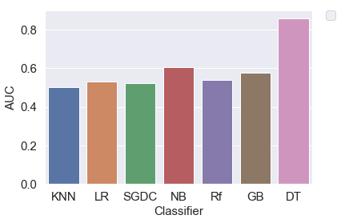

```python
ax = sns.barplot(x="classifier", y="auc", data=df_results)
ax.set_xlabel('Classifier',fontsize = 15)
ax.set_ylabel('AUC', fontsize = 15)
ax.tick_params(labelsize=15)

# Put the legend out of the figure
plt.legend(bbox_to_anchor=(1.05, 1), loc=2, borderaxespad=0., fontsize = 15)
plt.show()
```

This graph shows the Accuracy Score for K fold dataset modeling and experiment

```
No handles with labels found to put in legend.
```

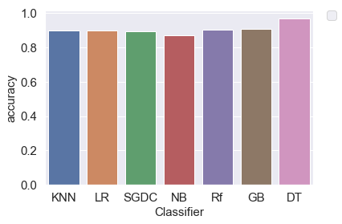

```python
ax = sns.barplot(x="classifier", y="accuracy", data=df_results)
ax.set_xlabel('Classifier',fontsize = 15)
ax.set_ylabel('accuracy', fontsize = 15)
ax.tick_params(labelsize=15)

# Put the legend out of the figure
plt.legend(bbox_to_anchor=(1.05, 1), loc=2, borderaxespad=0., fontsize = 15)
plt.show()
```

Lets make a dataframe for train test split datasets

```python
df_results = pd.DataFrame({'classifier':['KNN','LR','SGDC','NB','Rf','GB','DT'],
                          'auc':[auc_knn,auc_lr,auc_sgd,nb_train_auc_nb,rf_train_auc_rf,gb_train_aucp,tree_train_auc_tr],
                          'accuracy':[accuracy_knn,accuracy_lr,accuracy_sgd,nb_train_accuracy_nb,rf_train_accuracy_rf,gb_train_accuracyp,tree_train_accuracy_tr]})
```

This graph shows the AUC Score for randomly selected train test dataset modeling and experiment

```
No handles with labels found to put in legend.
```

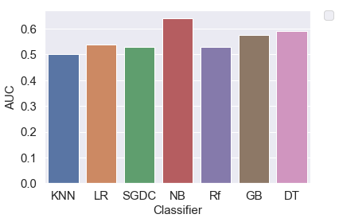

```python
ax = sns.barplot(x="classifier", y="auc", data=df_results)
ax.set_xlabel('Classifier',fontsize = 15)
ax.set_ylabel('AUC', fontsize = 15)
ax.tick_params(labelsize=15)

# Put the legend out of the figure
plt.legend(bbox_to_anchor=(1.05, 1), loc=2, borderaxespad=0., fontsize = 15)
plt.show()
```

This graph shows the Accuracy Score for randomly selected train test dataset modeling and experiment

```
No handles with labels found to put in legend.
```

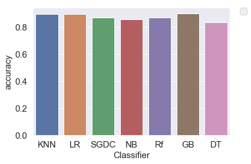

```python
ax = sns.barplot(x="classifier", y="accuracy", data=df_results)
ax.set_xlabel('Classifier',fontsize = 15)
ax.set_ylabel('accuracy', fontsize = 15)
ax.tick_params(labelsize=15)

# Put the legend out of the figure
plt.legend(bbox_to_anchor=(1.05, 1), loc=2, borderaxespad=0., fontsize = 15)
plt.show()
```

# FEATURE IMPORTANCE

The data is first converted into normalized data.

```python
from sklearn.preprocessing import StandardScaler

scaler  = StandardScaler()
scaler.fit(X_train)
#y_train_scaled=scaler.fit(y_train)
```

```
StandardScaler(copy=True, with_mean=True, with_std=True)
```

```python
X_train_tf = scaler.transform(X_train)
X_test_tf = scaler.transform(X_test)
```

# Feature Importance with Logistic Regression

```python
from sklearn.linear_model import LogisticRegression
lr=LogisticRegression(random_state = 42)
lr.fit(X_train, y_train)
```

```
LogisticRegression(C=1.0, class_weight=None, dual=False, fit_intercept=True,
          intercept_scaling=1, max_iter=100, multi_class='warn',
          n_jobs=None, penalty='l2', random_state=42, solver='warn',
          tol=0.0001, verbose=0, warm_start=False)
```

```python
df_final_c=df_c.drop(columns=['convert_30','revenue_30'])
X_trainc=df_final_c
X_testc=df_final_c
y_trainc=df_c[['convert_30']]
y_testc=df_c[['convert_30']]
#y_test = df1['convert_30']
print (X_trainc.shape, y_trainc.shape)
print (X_testc.shape)
cols_2=X_trainc.columns
cols_2
```

```
(28126, 181) (28126, 1)
(28126, 181)
```

```
Index(['cuid', 'roll_up', 'currentstatus', 'companytypegroup', 'team',
       'customersource', 'accrole', 'num_employees', 'num_purchases_year',
       'cost_purchases_year',
       ...
       'percemailopenedyearsixty', 'percemailclickedone',
       'percemailclickedthreeone', 'percemailclickedseventhree',
       'percemailclickedthirtyseven', 'percemailclickedsixtythirty',
       'percemailclickedyearsixty', 'currentapplicability', 'numemaillist',
       'dayssinceenrollment'],
      dtype='object', length=181)
```

```python
feature_importances = pd.DataFrame(lr.coef_[0],
                                   index = cols_2,
                                    columns=['importance']).sort_values('importance',
                                                                        ascending=False)
```

```python
feature_importances.head()
```

|  | importance |
| --- | --- |
| totalcalldurationseventhree | 0.000423 |
| avgatcprice | 0.000353 |
| totalrev | 0.000276 |
| sumrevseventhree | 0.000272 |
| numtotalpageviewsseventhree | 0.000214 |

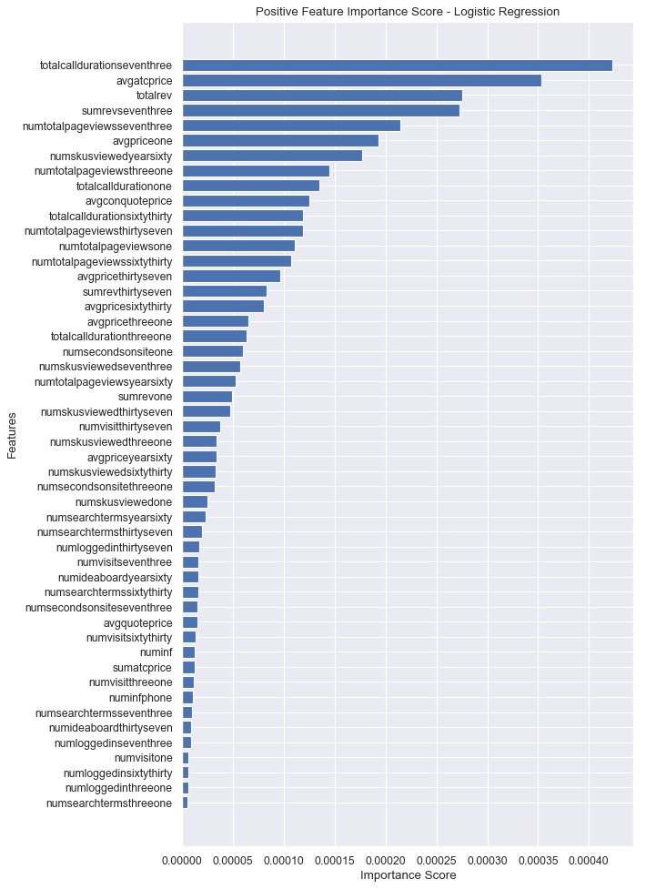

```python
num = np.min([50, len(cols_2)])
ylocs = np.arange(num)
# get the feature importance for top num and sort in reverse order
values_to_plot = feature_importances.iloc[:num].values.ravel()[::-1]
feature_labels = list(feature_importances.iloc[:num].index)[::-1]

plt.figure(num=None, figsize=(8, 15), dpi=80, facecolor='w', edgecolor='k');
plt.barh(ylocs, values_to_plot, align = 'center')
plt.ylabel('Features')
plt.xlabel('Importance Score')
plt.title('Positive Feature Importance Score - Logistic Regression')
plt.yticks(ylocs, feature_labels)
plt.show()
```

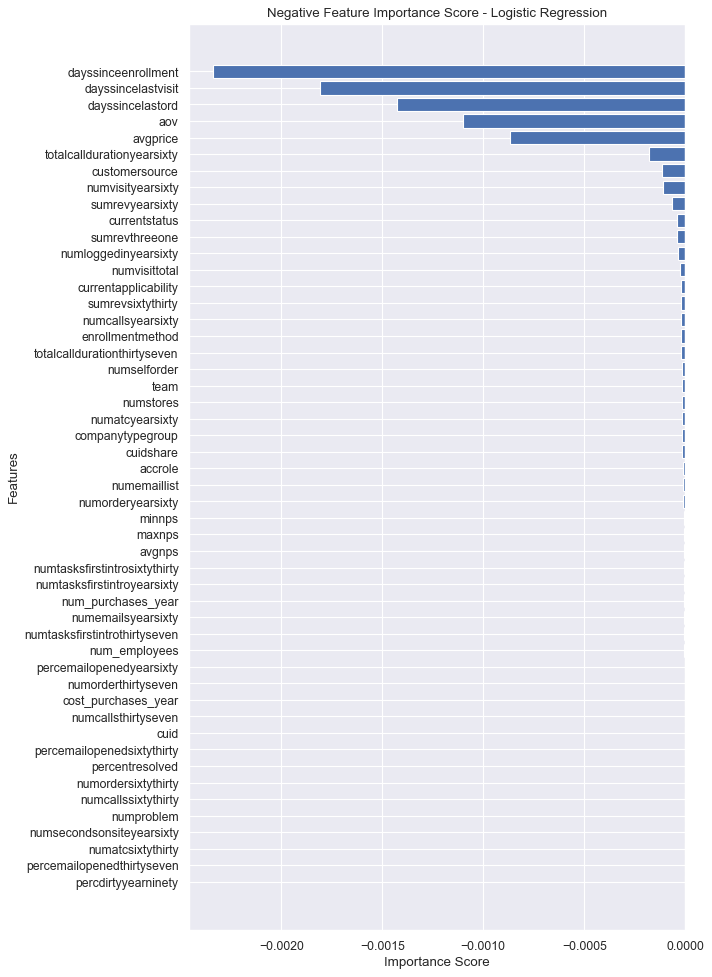

```python
values_to_plot = feature_importances.iloc[-num:].values.ravel()
feature_labels = list(feature_importances.iloc[-num:].index)

plt.figure(num=None, figsize=(8, 15), dpi=80, facecolor='w', edgecolor='k');
plt.barh(ylocs, values_to_plot, align = 'center')
plt.ylabel('Features')
plt.xlabel('Importance Score')
plt.title('Negative Feature Importance Score - Logistic Regression')
plt.yticks(ylocs, feature_labels)
plt.show()
```

# Feature Importance with Random Forest Classification

```python
from sklearn.ensemble import RandomForestClassifier
rf=RandomForestClassifier(max_depth = 6, random_state = 42)
rf.fit(X_trainc, y_trainc)
```

```
RandomForestClassifier(bootstrap=True, class_weight=None, criterion='gini',
            max_depth=6, max_features='auto', max_leaf_nodes=None,
            min_impurity_decrease=0.0, min_impurity_split=None,
            min_samples_leaf=1, min_samples_split=2,
            min_weight_fraction_leaf=0.0, n_estimators=10, n_jobs=None,
            oob_score=False, random_state=42, verbose=0, warm_start=False)
```

```python
feature_importances2 = pd.DataFrame(rf.feature_importances_,
                                   index = cols_2,
                                    columns=['importance']).sort_values('importance',
                                                                        ascending=False)
```

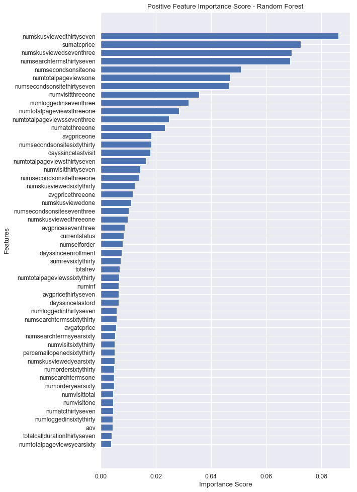

```python
num = np.min([50, len(cols_2)])
ylocs = np.arange(num)
# get the feature importance for top num and sort in reverse order
values_to_plot = feature_importances2.iloc[:num].values.ravel()[::-1]
feature_labels = list(feature_importances2.iloc[:num].index)[::-1]

plt.figure(num=None, figsize=(8, 15), dpi=80, facecolor='w', edgecolor='k');
plt.barh(ylocs, values_to_plot, align = 'center')
plt.ylabel('Features')
plt.xlabel('Importance Score')
plt.title('Positive Feature Importance Score - Random Forest')
plt.yticks(ylocs, feature_labels)
plt.show()
```

[figure not shown]

```python
values_to_plot = feature_importances2.iloc[-num:].values.ravel()
feature_labels = list(feature_importances2.iloc[-num:].index)

plt.figure(num=None, figsize=(8, 15), dpi=80, facecolor='w', edgecolor='k');
plt.barh(ylocs, values_to_plot, align = 'center')
plt.ylabel('Features')
plt.xlabel('Importance Score')
plt.title('Negative Feature Importance Score - Random Forest')
plt.yticks(ylocs, feature_labels)
plt.show()
```

Feature Importance with Gradient Boosting

```python
from sklearn.ensemble import GradientBoostingClassifier
gbc =GradientBoostingClassifier(n_estimators=100, learning_rate=1.0,
     max_depth=3, random_state=42)
gbc.fit(X_trainc, y_trainc)
feature_importances3 = pd.DataFrame(gbc.feature_importances_,
                                   index = cols_2,
                                    columns=['importance']).sort_values('importance',
                                                                        ascending=False)
```

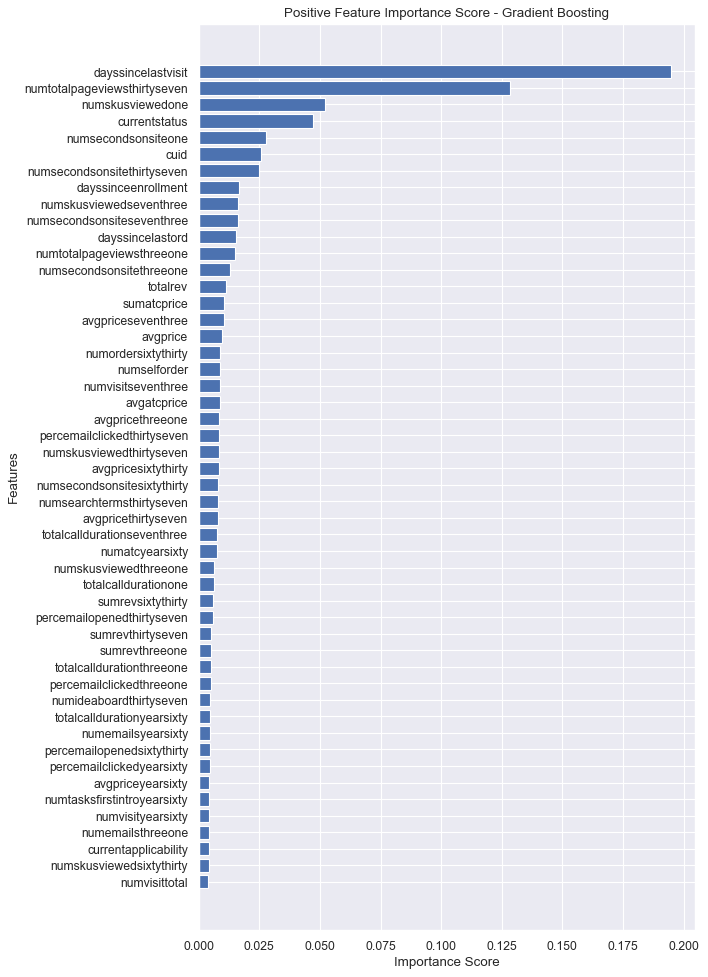

```python
num = np.min([50, len(cols_2)])
ylocs = np.arange(num)
# get the feature importance for top num and sort in reverse order
values_to_plot = feature_importances3.iloc[:num].values.ravel()[::-1]
feature_labels = list(feature_importances3.iloc[:num].index)[::-1]

plt.figure(num=None, figsize=(8, 15), dpi=80, facecolor='w', edgecolor='k');
plt.barh(ylocs, values_to_plot, align = 'center')
plt.ylabel('Features')
plt.xlabel('Importance Score')
plt.title('Positive Feature Importance Score - Gradient Boosting')
plt.yticks(ylocs, feature_labels)
plt.show()
```

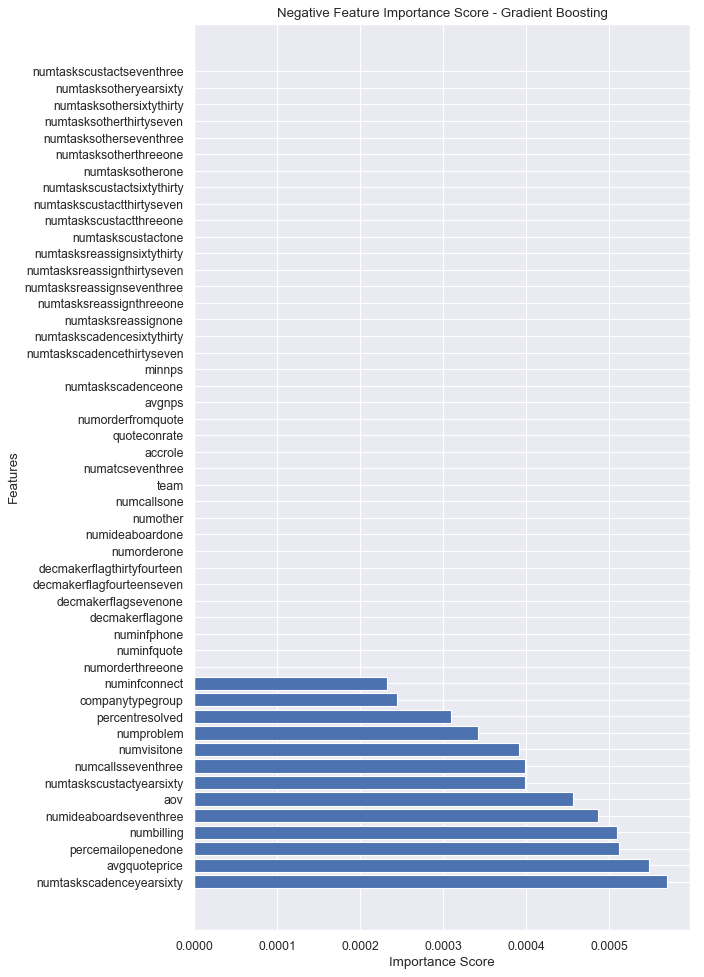

```python
values_to_plot = feature_importances3.iloc[-num:].values.ravel()
feature_labels = list(feature_importances3.iloc[-num:].index)

plt.figure(num=None, figsize=(8, 15), dpi=80, facecolor='w', edgecolor='k');
plt.barh(ylocs, values_to_plot, align = 'center')
plt.ylabel('Features')
plt.xlabel('Importance Score')
plt.title('Negative Feature Importance Score - Gradient Boosting')
plt.yticks(ylocs, feature_labels)
plt.show()
```

# Optimization

```python
df_e.shape
y_train=df_e[['convert_30']]

y_train.shape
df_final_d=df_e.drop(columns=['convert_30','revenue_30'])
X_train=df_final_d
X_test=df_final_d
y_train=df_e[['convert_30']]
y_test=df_e[['convert_30']]
#y_test = df1['convert_30']
```

# Running optimization with random Forest classification

```python
from sklearn.model_selection import train_test_split
X_train, X_test, y_train, y_test = train_test_split(X_train, y_train, test_size=0.33, random_state=42)

from sklearn.preprocessing import StandardScaler
scaler  = StandardScaler()
x1=scaler.fit(X_train)
x2=scaler.fit(X_test)
X_train_tf = x1.transform(X_train)
X_test_tf = x2.transform(X_test)
print (X_train_tf.shape, y_train.shape)
print (X_test_tf.shape)
```

```
(18844, 181) (18844, 1)
(9282, 181)
```

```python
from sklearn.metrics import make_scorer, roc_auc_score
from sklearn.ensemble import RandomForestClassifier

auc_scoring = make_scorer(roc_auc_score)
rf = RandomForestClassifier()
from sklearn.model_selection import RandomizedSearchCV

# number of trees
n_estimators = range(200,1000,200)
# maximum number of features to use at each split
max_features = ['auto','sqrt']
# maximum depth of the tree
max_depth = range(2,20,2)
# minimum number of samples to split a node
min_samples_split = range(2,10,2)
# criterion for evaluating a split
criterion = ['gini','entropy']

# random grid

random_grid = {'n_estimators':n_estimators,
              'max_features':max_features,
              'max_depth':max_depth,
              'min_samples_split':min_samples_split,
              'criterion':criterion}
rf = RandomForestClassifier()

# create the randomized search cross-validation
rf_random = RandomizedSearchCV(estimator = rf, param_distributions = random_grid,
                               n_iter = 20, cv = 2,
                               scoring=auc_scoring,verbose = 1, random_state = 42)

print(random_grid)
from sklearn.ensemble import RandomForestClassifier
rf=RandomForestClassifier(max_depth = 6, random_state = 42)
rf.fit(X_train_tf, y_train)

y_train_preds = rf.predict_proba(X_test_tf)[:,1]
#y_valid_preds = rf.predict_proba(X_valid_tf)[:,1]

thresh = 0.5

print('Baseline Random Forest')
rf_train_base_auc = roc_auc_score(y_test, y_train_preds)
#rf_valid_base_auc = roc_auc_score(y_valid, y_valid_preds)

print('Baseline AUC:%.3f'%(rf_train_base_auc))
#print('Validation AUC:%.3f'%(rf_valid_base_auc))
```

```
{'n_estimators': range(200, 1000, 200), 'max_features': ['auto', 'sqrt'], 'max_depth': range(2, 20, 2), 'min_samples_split': range(2, 10, 2), 'criterion': ['gini', 'entropy']}
Baseline Random Forest
Baseline AUC:0.801
```

```python
print('Optimized Random Forest')
import time
# fit the random search model (this will take a few minutes)
t1 = time.time()
rf_random.fit(X_train_tf, y_train)
t2 = time.time()
print(t2-t1)
y_train_preds_random = rf_random.best_estimator_.predict_proba(X_test_tf)[:,1]
#y_valid_preds_random = rf_random.best_estimator_.predict_proba(X_valid_tf)[:,1]

rf_train_opt_auc = roc_auc_score(y_test, y_train_preds_random)
#rf_valid_opt_auc = roc_auc_score(y_valid, y_valid_preds_random)
print("accuracy:%.3f"%rf_train_opt_auc)
print('Optimized AUC:%.3f'%rf_train_opt_auc)
```

```
Optimized Random Forest
Fitting 2 folds for each of 20 candidates, totalling 40 fits
```

[output not shown]

[output cut: 69 more lines]

[output not shown]

```
459.5031318664551
accuracy:0.815
Optimized AUC:0.815
```

# Running Optimization with gradient boosting

```python
from sklearn.model_selection import RandomizedSearchCV
auc_scoring = make_scorer(roc_auc_score)
from sklearn.ensemble import GradientBoostingClassifier
gbc =GradientBoostingClassifier(n_estimators=100, learning_rate=1.0,
     max_depth=3, random_state=42)
gbc.fit(X_train_tf, y_train)
# number of trees
n_estimators = range(50,200,50)

# maximum depth of the tree
max_depth = range(1,5,1)

# learning rate
learning_rate = [0.001,0.01,0.1,0.2]

# random grid

random_grid_gbc = {'n_estimators':n_estimators,
              'max_depth':max_depth,
              'learning_rate':learning_rate}

# create the randomized search cross-validation
gbc_random = RandomizedSearchCV(estimator = gbc, param_distributions = random_grid_gbc, n_iter = 20, cv = 2, scoring=auc_scoring,verbose = 0, random_state = 42)

t1 = time.time()
gbc_random.fit(X_train_tf, y_train)
t2 = time.time()
print(t2-t1)
```

[output not shown]

[output cut: 112 more lines]

[output not shown]

```
207.05111503601074
```

```python
y_train_preds = gbc.predict_proba(X_test_tf)[:,1]
#y_valid_preds = gbc.predict_proba(X_valid_tf)[:,1]

thresh = 0.5

print('Baseline gbc')
gbc_train_base_auc = roc_auc_score(y_test, y_train_preds)
#gbc_valid_base_auc = roc_auc_score(y_valid, y_valid_preds)

print('Training AUC:%.3f'%(gbc_train_base_auc))
#print('Validation AUC:%.3f'%(gbc_valid_base_auc))
print('Optimized gbc')
y_train_preds_random = gbc_random.best_estimator_.predict_proba(X_train_tf)[:,1]
#y_valid_preds_random = gbc_random.best_estimator_.predict_proba(X_valid_tf)[:,1]
gbc_train_opt_auc = roc_auc_score(y_train, y_train_preds_random)
#gbc_valid_opt_auc = roc_auc_score(y_valid, y_valid_preds_random)

print('Otimized AUC:%.3f'%(gbc_train_opt_auc))
#print('Validation AUC:%.3f'%(gbc_valid_opt_auc))
```

```
Baseline gbc
Training AUC:0.755
Optimized gbc
Otimized AUC:0.861
```

# Running Optimization Naive byes

```python
bounds = {
    'max_depth':(5,10),
    'ntrees': (100,500),
    'min_rows':(10,30),
   'learn_rate':(0.001, 0.01),
    'sample_rate':(0.5,0.8),
   'col_sample_rate':(0.5,0.8)
}

from sklearn.naive_bayes import GaussianNB
#from bayes_opt import BayesianOptimization

nb =GaussianNB()
nb.fit(X_train_tf, y_train)
# number of trees
n_estimators = range(50,200,50)

# maximum depth of the tree
max_depth = range(1,5,1)

# learning rate
learning_rate = [0.001,0.01,0.1]

# random grid

random_grid_nb = {#'n_estimators':n_estimators
                  #'max_depth':max_depth,
                  #'learn_rate':learning_rate
                 }

# create the randomized search cross-validation
nb_random = RandomizedSearchCV(estimator = nb, param_distributions =random_grid_nb,  n_iter = 20, cv = 2, scoring=auc_scoring,verbose = 0, random_state = 42)
import time
t1 = time.time()
nb_random.fit(X_train_tf, y_train)
t2 = time.time()
print(t2-t1)
```

```
0.4902646541595459
```

```python
y_train_preds = nb.predict_proba(X_test_tf)[:,1]
#y_valid_preds = gbc.predict_proba(X_valid_tf)[:,1]

thresh = 0.5

print('Baseline nb')
#nb_train_base_auc = roc_auc_score(y_test, y_train_preds)
#gbc_valid_base_auc = roc_auc_score(y_valid, y_valid_preds)

print('Training AUC:%.3f'%(nb_train_auc_nb))
#print('Validation AUC:%.3f'%(gbc_valid_base_auc))
print('Optimized nb')
y_train_preds_random = nb_random.best_estimator_.predict_proba(X_train_tf)[:,1]
#y_valid_preds_random = gbc_random.best_estimator_.predict_proba(X_valid_tf)[:,1]
nb_train_opt_auc = roc_auc_score(y_train, y_train_preds_random)
#gbc_valid_opt_auc = roc_auc_score(y_valid, y_valid_preds_random)

print('Training AUC:%.3f'%(nb_train_opt_auc))
#print('Validation AUC:%.3f'%(gbc_valid_opt_auc))
```

```
Baseline nb
Training AUC:0.639
Optimized nb
Training AUC:0.763
```

Putting results of the optimized model in a dataframe

```python
df_results3 = pd.DataFrame({'classifier':['RandomForest','RandomForest','GradientBoosting','GradientBoosting','NaiveBayes','NaiveBayes'],
                           'data_set':['baseline','optimized']*3,
                          'auc':[rf_train_base_auc,rf_train_opt_auc,
                                 gbc_train_base_auc,gbc_train_opt_auc,
                                 nb_train_auc_nb,nb_train_opt_auc],
                          })
```

# The comparison between baseline and optimized model scores

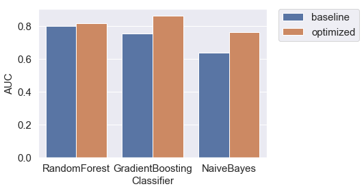

```python
import seaborn as sns
import matplotlib.pyplot as plt
sns.set(style="darkgrid")

ax = sns.barplot(x="classifier", y="auc", hue="data_set", data=df_results3)
ax.set_xlabel('Classifier',fontsize = 15)
ax.set_ylabel('AUC', fontsize = 15)
ax.tick_params(labelsize=15)
# Put the legend out of the figure
plt.legend(bbox_to_anchor=(1.05, 1), loc=2, borderaxespad=0., fontsize = 15)

plt.show()
```

Conclusion: After analysing the optimization, we came up with a conclusion that gradient boosting is a better model for this classification problem

# The ROC/AUC curve for normalized data and Gradient Boosting

```python
df_e.shape
y_train=df_e[['convert_30']]

y_train.shape
df_final_d=df_e.drop(columns=['convert_30','revenue_30'])
X_train=df_final_d
X_test=df_final_d
y_train=df_e[['convert_30']]
y_test=df_e[['convert_30']]
#y_test = df1['convert_30']
```

```python
from sklearn.model_selection import train_test_split
X_train, X_test, y_train, y_test = train_test_split(X_train, y_train, test_size=0.33, random_state=42)
```

```python
from sklearn.preprocessing import StandardScaler
scaler  = StandardScaler()
x1=scaler.fit(X_train)
x2=scaler.fit(X_test)
X_train_tf = x1.transform(X_train)
X_test_tf = x2.transform(X_test)
print (X_train_tf.shape, y_train.shape)
print (X_test_tf.shape)
```

```
(18844, 181) (18844, 1)
(9282, 181)
```

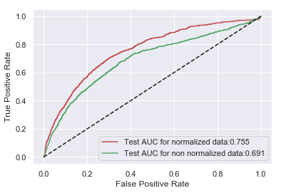

```python
from sklearn.metrics import roc_curve
y_train_preds = gbc.predict_proba(X_test)[:,1]
y_train_preds_norm=gbc.predict_proba(X_test_tf)[:,1]

fpr_test_norm, tpr_test_norm, thresholds_test_norm = roc_curve(y_test, y_train_preds_norm)
fpr_test, tpr_test, thresholds_test = roc_curve(y_test, y_train_preds)
auc_test = roc_auc_score(y_test, y_train_preds)
auc_test_norm=roc_auc_score(y_test, y_train_preds_norm)

plt.plot(fpr_test_norm, tpr_test_norm, 'r-',label ='Test AUC for normalized data:%.3f'%auc_test_norm)
plt.plot(fpr_test, tpr_test, 'g-',label ='Test AUC for non normalized data:%.3f'%auc_test)
plt.plot([0,1],[0,1],'k--')
plt.xlabel('False Positive Rate')
plt.ylabel('True Positive Rate')
plt.legend()
plt.show()
```

# The Output File to CSV

```python
X_test0=df1
X_test0.head()
```

|  | cuid | roll_up | currentstatus | companytypegroup | team | customersource | accrole | num_employees | num_purchases_year | cost_purchases_year | ... | percemailopenedyearsixty | percemailclickedone | percemailclickedthreeone | percemailclickedseventhree | percemailclickedthirtyseven | percemailclickedsixtythirty | percemailclickedyearsixty | currentapplicability | numemaillist | dayssinceenrollment |
| --- | --- | --- | --- | --- | --- | --- | --- | --- | --- | --- | --- | --- | --- | --- | --- | --- | --- | --- | --- | --- | --- |
| 0 | 16838 | 1 | 2 | 1 | 1 | 7 | 0 | 1 | 1 | 1 | ... | 0.025806 | 0.0 | 0.0 | 0.0 | 0.021739 | 0.012821 | 0.032258 | 5.0 | 2.0 | 86 |
| 1 | 532175 | 1 | 2 | 1 | 1 | 12 | 0 | 3 | 0 | 0 | ... | 0.000000 | 0.0 | 0.0 | 0.0 | 0.000000 | 0.000000 | 0.000000 | 0.0 | 0.0 | 3 |
| 2 | 532176 | 1 | 2 | 1 | 1 | 7 | 0 | 4 | 2 | 2 | ... | 0.036190 | 0.0 | 0.0 | 0.0 | 0.000000 | 0.000000 | 0.015238 | 8.0 | 4.0 | 13 |
| 3 | 532187 | 1 | 2 | 1 | 1 | 7 | 2 | 0 | 0 | 0 | ... | 1.000000 | 0.0 | 0.0 | 0.5 | 0.272727 | 0.250000 | 0.000000 | 0.0 | 0.0 | 10 |
| 4 | 16938 | 1 | 2 | 0 | 1 | 8 | 2 | 0 | 0 | 0 | ... | 0.049383 | 0.5 | 0.0 | 0.0 | 0.000000 | 0.043478 | 0.016461 | 5.0 | 2.0 | 42 |

5 rows × 181 columns

```python
model_final=gbc.fit(X_train, y_train)
y_train_preds_p = model_final.predict(X_test0)
```

```python
idx = 1
 # can be a list, a Series, an array or a scalar
X_test0.insert(loc=idx, column='Convert_30', value=y_train_preds_p)
```

```python
X_test0.head()
```

|  | cuid | Convert_30 | roll_up | currentstatus | companytypegroup | team | customersource | accrole | num_employees | num_purchases_year | ... | percemailopenedyearsixty | percemailclickedone | percemailclickedthreeone | percemailclickedseventhree | percemailclickedthirtyseven | percemailclickedsixtythirty | percemailclickedyearsixty | currentapplicability | numemaillist | dayssinceenrollment |
| --- | --- | --- | --- | --- | --- | --- | --- | --- | --- | --- | --- | --- | --- | --- | --- | --- | --- | --- | --- | --- | --- |
| 0 | 16838 | 0 | 1 | 2 | 1 | 1 | 7 | 0 | 1 | 1 | ... | 0.025806 | 0.0 | 0.0 | 0.0 | 0.021739 | 0.012821 | 0.032258 | 5.0 | 2.0 | 86 |
| 1 | 532175 | 0 | 1 | 2 | 1 | 1 | 12 | 0 | 3 | 0 | ... | 0.000000 | 0.0 | 0.0 | 0.0 | 0.000000 | 0.000000 | 0.000000 | 0.0 | 0.0 | 3 |
| 2 | 532176 | 1 | 1 | 2 | 1 | 1 | 7 | 0 | 4 | 2 | ... | 0.036190 | 0.0 | 0.0 | 0.0 | 0.000000 | 0.000000 | 0.015238 | 8.0 | 4.0 | 13 |
| 3 | 532187 | 1 | 1 | 2 | 1 | 1 | 7 | 2 | 0 | 0 | ... | 1.000000 | 0.0 | 0.0 | 0.5 | 0.272727 | 0.250000 | 0.000000 | 0.0 | 0.0 | 10 |
| 4 | 16938 | 0 | 1 | 2 | 0 | 1 | 8 | 2 | 0 | 0 | ... | 0.049383 | 0.5 | 0.0 | 0.0 | 0.000000 | 0.043478 | 0.016461 | 5.0 | 2.0 | 42 |

5 rows × 182 columns

# Regression for revenue_30

The folowing part of the code should be avoided since still working on it.

Here the distribution of the data is visualized

```
 mu = 75.04 and sigma = 508.87
```

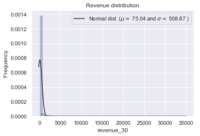

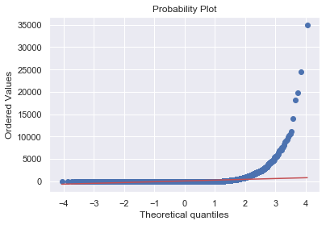

```
Skewness: 25.607793
Kurtosis: 1207.760159
```

```python
import seaborn as sns
import warnings

from scipy.stats import skew
from scipy import stats
from scipy.stats.stats import pearsonr
from scipy.stats import norm
from collections import Counter
sns.distplot(df['revenue_30'] , fit=norm);

# Get the fitted parameters used by the function
(mu, sigma) = norm.fit(df['revenue_30'])
print( '\n mu = {:.2f} and sigma = {:.2f}\n'.format(mu, sigma))
plt.legend(['Normal dist. ($\mu=$ {:.2f} and $\sigma=$ {:.2f} )'.format(mu, sigma)],
            loc='best')
plt.ylabel('Frequency')
plt.title('Revenue distribution')

fig = plt.figure()
res = stats.probplot(df['revenue_30'], plot=plt)
plt.show()

print("Skewness: %f" % df['revenue_30'].skew())
print("Kurtosis: %f" % df['revenue_30'].kurt())
```

```
There are 2928 visitors in the train dataset having non zero total transaction revenue
```

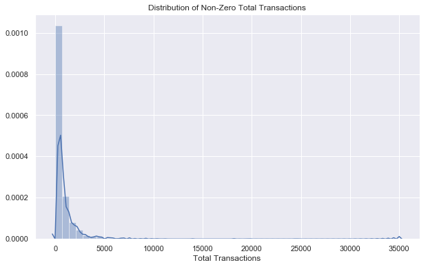

```python
non_zero = df[df["revenue_30"] > 0]["revenue_30"]
print ("There are " + str(len(non_zero)) + " visitors in the train dataset having non zero total transaction revenue")

plt.figure(figsize=(10,6))
sns.distplot(non_zero)
plt.title("Distribution of Non-Zero Total Transactions");
plt.xlabel("Total Transactions");
```

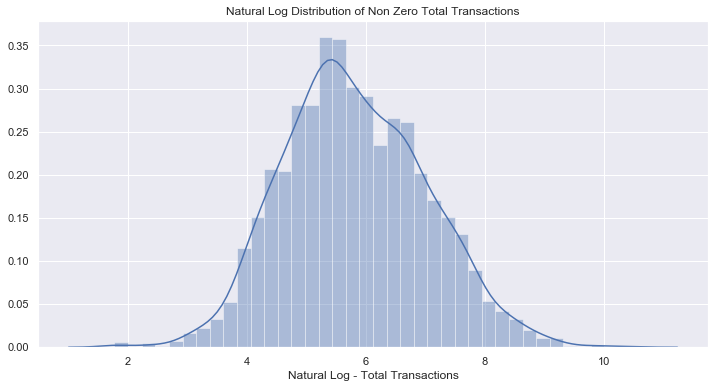

```python
plt.figure(figsize=(12,6))
sns.distplot(np.log1p(non_zero))
plt.title("Natural Log Distribution of Non Zero Total Transactions");
plt.xlabel("Natural Log - Total Transactions");
```

```python
df_final_ab=df.drop(columns=['revenue_30'])
X_train=df_final_ab
X_test=df_final_ab
y_train=df_i[['revenue_30']]
y_test=df_i[['revenue_30']]
#y_test = df1['convert_30']
print (X_train.shape, y_train.shape)
print (X_test.shape)
```

```
(28126, 182) (28126, 1)
(28126, 182)
```

```python
from sklearn.preprocessing import StandardScaler

scaler  = StandardScaler()
scaler.fit(X_train)
```

```
StandardScaler(copy=True, with_mean=True, with_std=True)
```

```python
X_train = scaler.transform(X_train)
X_test= scaler.transform(X_test)
```

```python
df_final_a=df.drop(columns=['revenue_30'])

df_a=df
```

```python
import xgboost as xgb
from sklearn.metrics import mean_squared_error
import pandas as pd
import numpy as np
```

```python
X_train=df_final_a
#X_test=df_final_a
y_train=df_a[['revenue_30']]
#y_test=df_a[['convert_30']]
#y_test = df1['convert_30']
#print (X_train.shape, y_train.shape)
#print (X_test.shape)
```

```python
data_dmatrix = xgb.DMatrix(data=X_train,label=y_train)
```

```python
from sklearn.model_selection import train_test_split


X_train, X_test, y_train, y_test = train_test_split(X_train, y_train, test_size=0.1, random_state=42)
```

```python
xg_reg = xgb.XGBRegressor(objective ='reg:linear', colsample_bytree = 0.3, learning_rate = 0.1,
                max_depth = 5, alpha = 10, n_estimators = 10)
```

```python
xg_reg.fit(X_train,y_train)

preds = xg_reg.predict(X_test)
```

```
[16:28:52] WARNING: src/objective/regression_obj.cu:152: reg:linear is now deprecated in favor of reg:squarederror.
```

```python
rmse_xgb =np.log(np.sqrt(mean_squared_error(y_test, preds)))
print("Xgb Boost RMSE: %.3f" % (rmse_xgb))
```

```
Xgb Boost RMSE: 6.066
```

```python
from sklearn.linear_model import LinearRegression
from sklearn.linear_model import Lasso
from sklearn.linear_model import Ridge
from sklearn.linear_model import ElasticNet
from sklearn.ensemble import RandomForestRegressor
from sklearn.ensemble import GradientBoostingRegressor
from sklearn.linear_model import LogisticRegression
```

```python
lm=LinearRegression()
lasso=Lasso()
rid=Ridge()
elas=ElasticNet()
random=RandomForestRegressor()
gb=GradientBoostingRegressor()
```

```python
lm.fit(X_train,y_train)
lasso.fit(X_train,y_train)
rid.fit(X_train,y_train)
elas.fit(X_train,y_train)
random.fit(X_train,y_train)
gb.fit(X_train,y_train)
```

```
GradientBoostingRegressor(alpha=0.9, criterion='friedman_mse', init=None,
             learning_rate=0.1, loss='ls', max_depth=3, max_features=None,
             max_leaf_nodes=None, min_impurity_decrease=0.0,
             min_impurity_split=None, min_samples_leaf=1,
             min_samples_split=2, min_weight_fraction_leaf=0.0,
             n_estimators=100, n_iter_no_change=None, presort='auto',
             random_state=None, subsample=1.0, tol=0.0001,
             validation_fraction=0.1, verbose=0, warm_start=False)
```

```python
preds = lm.predict(X_test)
rmse_lm = np.log(np.sqrt(mean_squared_error(y_test, preds)))
print("Linear Regression RMSE: %.3f" % (rmse_lm))
```

```
Linear Regression RMSE: 6.031
```

```python
preds = lasso.predict(X_test)
rmse_lasso =np.log(np.sqrt(mean_squared_error(y_test, preds)))
print("Lasso RMSE: %.3f" % (rmse_lasso))
```

```
Lasso RMSE: 5.980
```

```python
preds = rid.predict(X_test)
rmse_rid = np.log(np.sqrt(mean_squared_error(y_test, preds)))
print("Ridge RMSE: %.3f" %(rmse_rid))
```

```
Ridge RMSE: 6.031
```

```python
preds = lm.predict(X_test)
rmse_elas = np.log(np.sqrt(mean_squared_error(y_test, preds)))
print("ElasticNet RMSE: %.3f" % (rmse_elas))
```

```
ElasticNet RMSE: 6.031
```

```python
preds = random.predict(X_test)
rmse_random = np.log(np.sqrt(mean_squared_error(y_test, preds)))
print("Random Regression RMSE: %.3f" % (rmse_random))
```

```
Random Regression RMSE: 5.989
```

```python
preds = gb.predict(X_test)
rmse_gb = np.log(np.sqrt(mean_squared_error(y_test, preds)))
print("Gradient Boosting Regression RMSE: %.3f" % (rmse_gb))
```

```
Gradient Boosting Regression RMSE: 5.954
```

```python
df_results4 = pd.DataFrame({'classifier':['LR','Lasso','Ridge','ENet','XGB','RF','GB'],
                          'RMSE':[rmse_lm,rmse_lasso,rmse_rid,rmse_elas,rmse_xgb,rmse_random,rmse_gb],
                          })
```

```python
import seaborn as sns
import matplotlib.pyplot as plt
sns.set(style="darkgrid")
```

```
No handles with labels found to put in legend.
```

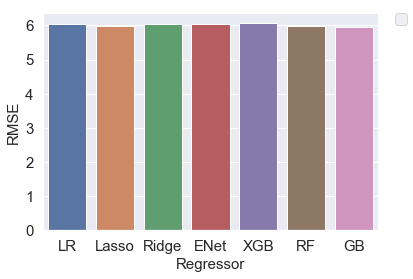

```python
ax = sns.barplot(x="classifier", y="RMSE", data=df_results4)
ax.set_xlabel('Regressor',fontsize = 15)
ax.set_ylabel('RMSE', fontsize = 15)
ax.tick_params(labelsize=15)

# Put the legend out of the figure
plt.legend(bbox_to_anchor=(1.05, 1), loc=2, borderaxespad=0., fontsize = 15)
plt.show()
```

```python
X_test1=X_test0
X_test1
```

|  | cuid | Convert_30 | roll_up | currentstatus | companytypegroup | team | customersource | accrole | num_employees | num_purchases_year | ... | percemailopenedyearsixty | percemailclickedone | percemailclickedthreeone | percemailclickedseventhree | percemailclickedthirtyseven | percemailclickedsixtythirty | percemailclickedyearsixty | currentapplicability | numemaillist | dayssinceenrollment |
| --- | --- | --- | --- | --- | --- | --- | --- | --- | --- | --- | --- | --- | --- | --- | --- | --- | --- | --- | --- | --- | --- |
| 0 | 16838 | 0 | 1 | 2 | 1 | 1 | 7 | 0 | 1 | 1 | ... | 0.025806 | 0.000000 | 0.000000 | 0.000000 | 0.021739 | 0.012821 | 0.032258 | 5.0 | 2.0 | 86 |
| 1 | 532175 | 0 | 1 | 2 | 1 | 1 | 12 | 0 | 3 | 0 | ... | 0.000000 | 0.000000 | 0.000000 | 0.000000 | 0.000000 | 0.000000 | 0.000000 | 0.0 | 0.0 | 3 |
| 2 | 532176 | 1 | 1 | 2 | 1 | 1 | 7 | 0 | 4 | 2 | ... | 0.036190 | 0.000000 | 0.000000 | 0.000000 | 0.000000 | 0.000000 | 0.015238 | 8.0 | 4.0 | 13 |
| 3 | 532187 | 1 | 1 | 2 | 1 | 1 | 7 | 2 | 0 | 0 | ... | 1.000000 | 0.000000 | 0.000000 | 0.500000 | 0.272727 | 0.250000 | 0.000000 | 0.0 | 0.0 | 10 |
| 4 | 16938 | 0 | 1 | 2 | 0 | 1 | 8 | 2 | 0 | 0 | ... | 0.049383 | 0.500000 | 0.000000 | 0.000000 | 0.000000 | 0.043478 | 0.016461 | 5.0 | 2.0 | 42 |
| 5 | 532189 | 0 | 1 | 3 | 1 | 1 | 0 | 0 | 5 | 0 | ... | 0.000000 | 0.000000 | 1.000000 | 0.500000 | 0.000000 | 0.000000 | 0.000000 | 0.0 | 0.0 | 5 |
| 6 | 16948 | 1 | 1 | 3 | 0 | 1 | 5 | 0 | 0 | 0 | ... | 0.108033 | 0.000000 | 0.000000 | 0.000000 | 0.062500 | 0.045455 | 0.008310 | 5.0 | 2.0 | 52 |
| 7 | 532197 | 1 | 1 | 2 | 0 | 1 | 0 | 0 | 2 | 0 | ... | 0.000000 | 0.500000 | 0.250000 | 0.000000 | 0.125000 | 0.250000 | 0.000000 | 11.0 | 1.0 | 1 |
| 8 | 17017 | 0 | 1 | 2 | 1 | 1 | 14 | 2 | 0 | 0 | ... | 0.045977 | 0.000000 | 0.250000 | 0.000000 | 0.000000 | 0.000000 | 0.034483 | 2.0 | 2.0 | 93 |
| 9 | 17020 | 0 | 1 | 3 | 1 | 1 | 7 | 0 | 4 | 3 | ... | 0.174312 | 0.000000 | 0.000000 | 0.000000 | 0.000000 | 0.000000 | 0.064220 | 0.0 | 0.0 | 71 |
| 10 | 532205 | 0 | 1 | 3 | 1 | 1 | 7 | 3 | 0 | 0 | ... | 0.352941 | 0.500000 | 0.000000 | 0.000000 | 0.040000 | 0.000000 | 0.032680 | 10.0 | 1.0 | 10 |
| 11 | 532211 | 0 | 1 | 2 | 0 | 1 | 7 | 0 | 1 | 0 | ... | 0.128596 | 0.000000 | 0.000000 | 0.000000 | 0.016393 | 0.024096 | 0.038917 | 10.0 | 2.0 | 8 |
| 12 | 17139 | 0 | 1 | 3 | 1 | 1 | 8 | 2 | 0 | 0 | ... | 1.000000 | 0.000000 | 0.000000 | 0.222222 | 0.071429 | 0.111111 | 0.300000 | 0.0 | 0.0 | 66 |
| 13 | 17267 | 0 | 1 | 2 | 1 | 1 | 14 | 0 | 2 | 2 | ... | 0.017857 | 0.000000 | 0.333333 | 0.000000 | 0.034483 | 0.047619 | 0.008929 | 5.0 | 1.0 | 46 |
| 14 | 532226 | 0 | 1 | 2 | 1 | 1 | 8 | 2 | 0 | 0 | ... | 0.000000 | 0.000000 | 0.000000 | 0.000000 | 0.000000 | 0.000000 | 0.000000 | 3.0 | 1.0 | 10 |
| 15 | 17291 | 0 | 1 | 2 | 0 | 1 | 7 | 0 | 0 | 0 | ... | 0.600000 | 0.000000 | 0.000000 | 0.000000 | 0.000000 | 0.000000 | 0.100000 | 0.0 | 0.0 | 50 |
| 16 | 17308 | 1 | 1 | 3 | 1 | 1 | 8 | 2 | 0 | 0 | ... | 1.000000 | 1.000000 | 0.125000 | 0.166667 | 0.246575 | 0.571429 | 0.000000 | 0.0 | 0.0 | 30 |
| 17 | 532231 | 0 | 1 | 3 | 1 | 1 | 12 | 2 | 0 | 0 | ... | 0.075200 | 0.333333 | 0.000000 | 0.000000 | 0.018692 | 0.019608 | 0.004800 | 10.0 | 2.0 | 23 |
| 18 | 17378 | 0 | 1 | 3 | 1 | 0 | 8 | 3 | 0 | 0 | ... | 0.424242 | 0.000000 | 0.000000 | 0.000000 | 0.050000 | 0.000000 | 0.222222 | 3.0 | 1.0 | 83 |
| 19 | 17390 | 0 | 1 | 3 | 1 | 1 | 8 | 0 | 2 | 3 | ... | 0.184701 | 0.000000 | 0.000000 | 0.000000 | 0.009346 | 0.023077 | 0.018657 | 7.0 | 2.0 | 116 |
| 20 | 17431 | 0 | 1 | 3 | 1 | 1 | 7 | 0 | 2 | 2 | ... | 0.061466 | 0.000000 | 0.000000 | 0.000000 | 0.047170 | 0.049383 | 0.026005 | 7.0 | 1.0 | 44 |
| 21 | 17478 | 0 | 1 | 2 | 1 | 1 | 8 | 0 | 1 | 0 | ... | 0.500000 | 0.000000 | 0.000000 | 0.000000 | 0.000000 | 0.153846 | 0.000000 | 0.0 | 0.0 | 55 |
| 22 | 17545 | 0 | 1 | 2 | 1 | 1 | 8 | 0 | 3 | 3 | ... | 0.031746 | 0.000000 | 0.000000 | 0.000000 | 0.037037 | 0.000000 | 0.015873 | 0.0 | 0.0 | 100 |
| 23 | 17572 | 0 | 1 | 2 | 1 | 1 | 7 | 0 | 1 | 3 | ... | 0.020833 | 0.000000 | 0.000000 | 0.000000 | 0.100000 | 0.090909 | 0.006944 | 5.0 | 2.0 | 48 |
| 24 | 17633 | 0 | 1 | 2 | 1 | 1 | 7 | 3 | 0 | 0 | ... | 0.591837 | 1.000000 | 0.000000 | 0.500000 | 0.250000 | 0.076923 | 0.190476 | 2.0 | 1.0 | 149 |
| 25 | 532266 | 0 | 1 | 2 | 1 | 1 | 14 | 0 | 3 | 4 | ... | 0.000000 | 0.000000 | 0.000000 | 0.000000 | 0.000000 | 0.000000 | 0.000000 | 0.0 | 1.0 | 3 |
| 26 | 532276 | 0 | 1 | 2 | 1 | 1 | 7 | 0 | 4 | 0 | ... | 0.000000 | 0.000000 | 0.000000 | 0.000000 | 0.000000 | 0.000000 | 0.000000 | 7.0 | 1.0 | 28 |
| 27 | 532286 | 0 | 1 | 2 | 1 | 1 | 0 | 0 | 1 | 2 | ... | 0.012739 | 0.000000 | 0.000000 | 0.000000 | 0.032787 | 0.000000 | 0.006369 | 5.0 | 2.0 | 23 |
| 28 | 17882 | 0 | 1 | 2 | 1 | 1 | 14 | 0 | 3 | 4 | ... | 0.088889 | 0.000000 | 0.166667 | 0.100000 | 0.125000 | 0.064516 | 0.037037 | 7.0 | 1.0 | 34 |
| 29 | 532296 | 0 | 1 | 2 | 1 | 1 | 7 | 0 | 5 | 3 | ... | 0.000000 | 0.000000 | 0.500000 | 0.000000 | 0.142857 | 0.400000 | 0.000000 | 0.0 | 1.0 | 2 |
| ... | ... | ... | ... | ... | ... | ... | ... | ... | ... | ... | ... | ... | ... | ... | ... | ... | ... | ... | ... | ... | ... |
| 30345 | 436179 | 0 | 0 | 2 | 1 | 1 | 7 | 0 | 4 | 3 | ... | 0.000000 | 0.000000 | 0.000000 | 0.000000 | 0.000000 | 0.000000 | 0.000000 | 0.0 | 0.0 | 111 |
| 30346 | 585768 | 1 | 0 | 2 | 0 | 0 | 8 | 2 | 0 | 0 | ... | 0.000000 | 0.000000 | 0.000000 | 0.000000 | 0.073171 | 0.000000 | 0.000000 | 5.0 | 1.0 | 16 |
| 30347 | 436256 | 0 | 0 | 2 | 1 | 1 | 7 | 2 | 2 | 3 | ... | 0.016949 | 0.000000 | 0.000000 | 0.000000 | 0.000000 | 0.000000 | 0.118644 | 0.0 | 0.0 | 108 |
| 30348 | 436275 | 0 | 0 | 3 | 1 | 0 | 7 | 2 | 0 | 0 | ... | 0.960630 | 0.000000 | 0.200000 | 0.625000 | 0.166667 | 0.270270 | 0.236220 | 7.0 | 1.0 | 191 |
| 30349 | 532066 | 0 | 0 | 3 | 1 | 1 | 14 | 2 | 0 | 0 | ... | 0.063063 | 0.000000 | 0.000000 | 0.000000 | 0.029412 | 0.028571 | 0.027027 | 3.0 | 1.0 | 196 |
| 30350 | 436290 | 0 | 0 | 2 | 1 | 1 | 7 | 0 | 0 | 0 | ... | 0.962085 | 0.000000 | 0.250000 | 0.166667 | 0.142857 | 0.058824 | 0.312796 | 0.0 | 0.0 | 193 |
| 30351 | 532074 | 0 | 0 | 2 | 1 | 1 | 12 | 2 | 0 | 0 | ... | 0.051282 | 0.000000 | 0.000000 | 0.000000 | 0.000000 | 0.000000 | 0.015385 | 3.0 | 1.0 | 189 |
| 30352 | 436556 | 0 | 0 | 2 | 1 | 1 | 14 | 0 | 0 | 0 | ... | 0.118557 | 0.000000 | 0.000000 | 0.000000 | 0.000000 | 0.000000 | 0.000000 | 5.0 | 1.0 | 182 |
| 30353 | 436601 | 1 | 0 | 3 | 1 | 1 | 5 | 2 | 0 | 0 | ... | 0.198864 | 0.000000 | 0.000000 | 0.500000 | 0.106383 | 0.115385 | 0.028409 | 7.0 | 1.0 | 178 |
| 30354 | 436613 | 0 | 0 | 2 | 1 | 1 | 7 | 0 | 0 | 0 | ... | 0.013699 | 0.000000 | 0.000000 | 0.000000 | 0.000000 | 0.000000 | 0.013699 | 0.0 | 0.0 | 179 |
| 30355 | 436618 | 0 | 0 | 3 | 1 | 1 | 7 | 2 | 0 | 0 | ... | 0.024691 | 0.000000 | 0.000000 | 0.000000 | 0.000000 | 0.000000 | 0.012346 | 1.0 | 1.0 | 179 |
| 30356 | 436681 | 0 | 0 | 3 | 0 | 1 | 8 | 2 | 0 | 0 | ... | 0.941176 | 0.000000 | 0.000000 | 0.000000 | 0.000000 | 0.000000 | 0.117647 | 0.0 | 0.0 | 170 |
| 30357 | 436720 | 0 | 0 | 2 | 0 | 1 | 7 | 0 | 0 | 0 | ... | 0.079646 | 0.000000 | 0.000000 | 0.000000 | 0.000000 | 0.000000 | 0.008850 | 7.0 | 1.0 | 168 |
| 30358 | 436749 | 0 | 0 | 3 | 1 | 1 | 7 | 0 | 0 | 0 | ... | 0.322835 | 0.000000 | 0.000000 | 0.000000 | 0.000000 | 0.093023 | 0.055118 | 7.0 | 1.0 | 166 |
| 30359 | 436751 | 0 | 0 | 2 | 1 | 1 | 12 | 0 | 0 | 0 | ... | 0.230769 | 0.000000 | 0.000000 | 0.000000 | 0.000000 | 0.000000 | 0.000000 | 0.0 | 0.0 | 155 |
| 30360 | 436760 | 0 | 0 | 2 | 0 | 1 | 7 | 0 | 0 | 0 | ... | 0.000000 | 0.000000 | 0.000000 | 0.000000 | 0.000000 | 0.000000 | 0.000000 | 0.0 | 0.0 | 163 |
| 30361 | 532094 | 0 | 0 | 2 | 1 | 1 | 7 | 0 | 2 | 2 | ... | 0.052632 | 0.000000 | 0.000000 | 0.000000 | 0.000000 | 0.000000 | 0.052632 | 3.0 | 1.0 | 71 |
| 30362 | 436869 | 0 | 0 | 2 | 1 | 1 | 8 | 2 | 0 | 0 | ... | 1.000000 | 0.000000 | 0.000000 | 0.000000 | 0.000000 | 0.000000 | 0.000000 | 0.0 | 0.0 | 35 |
| 30363 | 532102 | 0 | 0 | 2 | 1 | 1 | 14 | 0 | 3 | 3 | ... | 0.000000 | 0.000000 | 0.000000 | 0.000000 | 0.000000 | 0.020408 | 0.000000 | 0.0 | 0.0 | 62 |
| 30364 | 585781 | 0 | 0 | 2 | 0 | 1 | 7 | 0 | 2 | 0 | ... | 0.000000 | 0.000000 | 0.000000 | 0.000000 | 0.000000 | 0.000000 | 0.000000 | 0.0 | 0.0 | 22 |
| 30365 | 532131 | 0 | 0 | 2 | 1 | 1 | 7 | 0 | 3 | 3 | ... | 0.000000 | 0.000000 | 0.000000 | 0.000000 | 0.000000 | 0.285714 | 0.000000 | 0.0 | 0.0 | 33 |
| 30366 | 532132 | 0 | 0 | 2 | 0 | 1 | 7 | 0 | 2 | 0 | ... | 0.000000 | 0.000000 | 0.000000 | 0.000000 | 0.000000 | 0.000000 | 0.000000 | 7.0 | 1.0 | 30 |
| 30367 | 437218 | 0 | 0 | 3 | 1 | 1 | 7 | 0 | 2 | 2 | ... | 0.200000 | 0.500000 | 0.000000 | 0.000000 | 0.043478 | 0.072464 | 0.030000 | 0.0 | 0.0 | 123 |
| 30368 | 437223 | 0 | 0 | 2 | 1 | 1 | 8 | 3 | 0 | 0 | ... | 0.125000 | 0.000000 | 0.000000 | 0.000000 | 0.000000 | 0.000000 | 0.000000 | 3.0 | 1.0 | 119 |
| 30369 | 437260 | 0 | 0 | 2 | 0 | 1 | 7 | 0 | 2 | 1 | ... | 0.045455 | 0.000000 | 0.000000 | 0.000000 | 0.000000 | 0.000000 | 0.015152 | 3.0 | 1.0 | 113 |
| 30370 | 437269 | 0 | 0 | 2 | 0 | 1 | 5 | 0 | 1 | 0 | ... | 0.619048 | 0.000000 | 0.000000 | 0.000000 | 0.000000 | 0.000000 | 0.023810 | 13.0 | 1.0 | 107 |
| 30371 | 532137 | 0 | 0 | 3 | 1 | 1 | 8 | 2 | 0 | 0 | ... | 0.216216 | 0.000000 | 0.000000 | 0.000000 | 0.033333 | 0.000000 | 0.013514 | 7.0 | 1.0 | 106 |
| 30372 | 437287 | 0 | 0 | 3 | 1 | 1 | 7 | 0 | 1 | 1 | ... | 0.044118 | 0.000000 | 0.000000 | 0.000000 | 0.000000 | 0.000000 | 0.014706 | 3.0 | 1.0 | 106 |
| 30373 | 532142 | 0 | 0 | 2 | 1 | 1 | 14 | 0 | 1 | 2 | ... | 0.000000 | 0.000000 | 0.000000 | 0.000000 | 0.000000 | 0.000000 | 0.000000 | 3.0 | 1.0 | 42 |
| 30374 | 532158 | 0 | 0 | 2 | 1 | 1 | 7 | 3 | 0 | 0 | ... | 0.000000 | 0.000000 | 0.000000 | 0.000000 | 0.000000 | 0.052632 | 0.000000 | 0.0 | 0.0 | 50 |

30375 rows × 182 columns

SO as we can see the Gradient Boosting Regressor gives out the lowest RMSE score This is why I'll choose Gradient boosting regressor for prediciting the revenue.

```python
model_final=gb.fit(X_train, y_train)
y_train_preds_p2 = model_final.predict(X_test1)
```

```python
idx = 2
 # can be a list, a Series, an array or a scalar
X_test1.insert(loc=idx, column='Revenue_30', value=y_train_preds_p2)
```

```python
X_test1
```

|  | cuid | Convert_30 | Revenue_30 | roll_up | currentstatus | companytypegroup | team | customersource | accrole | num_employees | ... | percemailopenedyearsixty | percemailclickedone | percemailclickedthreeone | percemailclickedseventhree | percemailclickedthirtyseven | percemailclickedsixtythirty | percemailclickedyearsixty | currentapplicability | numemaillist | dayssinceenrollment |
| --- | --- | --- | --- | --- | --- | --- | --- | --- | --- | --- | --- | --- | --- | --- | --- | --- | --- | --- | --- | --- | --- |
| 0 | 16838 | 0 | -1.482021 | 1 | 2 | 1 | 1 | 7 | 0 | 1 | ... | 0.025806 | 0.000000 | 0.000000 | 0.000000 | 0.021739 | 0.012821 | 0.032258 | 5.0 | 2.0 | 86 |
| 1 | 532175 | 0 | 3.117012 | 1 | 2 | 1 | 1 | 12 | 0 | 3 | ... | 0.000000 | 0.000000 | 0.000000 | 0.000000 | 0.000000 | 0.000000 | 0.000000 | 0.0 | 0.0 | 3 |
| 2 | 532176 | 1 | 680.475910 | 1 | 2 | 1 | 1 | 7 | 0 | 4 | ... | 0.036190 | 0.000000 | 0.000000 | 0.000000 | 0.000000 | 0.000000 | 0.015238 | 8.0 | 4.0 | 13 |
| 3 | 532187 | 1 | 1548.518722 | 1 | 2 | 1 | 1 | 7 | 2 | 0 | ... | 1.000000 | 0.000000 | 0.000000 | 0.500000 | 0.272727 | 0.250000 | 0.000000 | 0.0 | 0.0 | 10 |
| 4 | 16938 | 0 | -1.482021 | 1 | 2 | 0 | 1 | 8 | 2 | 0 | ... | 0.049383 | 0.500000 | 0.000000 | 0.000000 | 0.000000 | 0.043478 | 0.016461 | 5.0 | 2.0 | 42 |
| 5 | 532189 | 0 | 1.668936 | 1 | 3 | 1 | 1 | 0 | 0 | 5 | ... | 0.000000 | 0.000000 | 1.000000 | 0.500000 | 0.000000 | 0.000000 | 0.000000 | 0.0 | 0.0 | 5 |
| 6 | 16948 | 1 | 597.291492 | 1 | 3 | 0 | 1 | 5 | 0 | 0 | ... | 0.108033 | 0.000000 | 0.000000 | 0.000000 | 0.062500 | 0.045455 | 0.008310 | 5.0 | 2.0 | 52 |
| 7 | 532197 | 1 | 848.869829 | 1 | 2 | 0 | 1 | 0 | 0 | 2 | ... | 0.000000 | 0.500000 | 0.250000 | 0.000000 | 0.125000 | 0.250000 | 0.000000 | 11.0 | 1.0 | 1 |
| 8 | 17017 | 0 | -1.911894 | 1 | 2 | 1 | 1 | 14 | 2 | 0 | ... | 0.045977 | 0.000000 | 0.250000 | 0.000000 | 0.000000 | 0.000000 | 0.034483 | 2.0 | 2.0 | 93 |
| 9 | 17020 | 0 | 2.099910 | 1 | 3 | 1 | 1 | 7 | 0 | 4 | ... | 0.174312 | 0.000000 | 0.000000 | 0.000000 | 0.000000 | 0.000000 | 0.064220 | 0.0 | 0.0 | 71 |
| 10 | 532205 | 0 | 75.329731 | 1 | 3 | 1 | 1 | 7 | 3 | 0 | ... | 0.352941 | 0.500000 | 0.000000 | 0.000000 | 0.040000 | 0.000000 | 0.032680 | 10.0 | 1.0 | 10 |
| 11 | 532211 | 0 | -1.800045 | 1 | 2 | 0 | 1 | 7 | 0 | 1 | ... | 0.128596 | 0.000000 | 0.000000 | 0.000000 | 0.016393 | 0.024096 | 0.038917 | 10.0 | 2.0 | 8 |
| 12 | 17139 | 0 | 6.455771 | 1 | 3 | 1 | 1 | 8 | 2 | 0 | ... | 1.000000 | 0.000000 | 0.000000 | 0.222222 | 0.071429 | 0.111111 | 0.300000 | 0.0 | 0.0 | 66 |
| 13 | 17267 | 0 | -1.911894 | 1 | 2 | 1 | 1 | 14 | 0 | 2 | ... | 0.017857 | 0.000000 | 0.333333 | 0.000000 | 0.034483 | 0.047619 | 0.008929 | 5.0 | 1.0 | 46 |
| 14 | 532226 | 0 | -1.912995 | 1 | 2 | 1 | 1 | 8 | 2 | 0 | ... | 0.000000 | 0.000000 | 0.000000 | 0.000000 | 0.000000 | 0.000000 | 0.000000 | 3.0 | 1.0 | 10 |
| 15 | 17291 | 0 | -1.608844 | 1 | 2 | 0 | 1 | 7 | 0 | 0 | ... | 0.600000 | 0.000000 | 0.000000 | 0.000000 | 0.000000 | 0.000000 | 0.100000 | 0.0 | 0.0 | 50 |
| 16 | 17308 | 1 | 1967.164817 | 1 | 3 | 1 | 1 | 8 | 2 | 0 | ... | 1.000000 | 1.000000 | 0.125000 | 0.166667 | 0.246575 | 0.571429 | 0.000000 | 0.0 | 0.0 | 30 |
| 17 | 532231 | 0 | -9.290420 | 1 | 3 | 1 | 1 | 12 | 2 | 0 | ... | 0.075200 | 0.333333 | 0.000000 | 0.000000 | 0.018692 | 0.019608 | 0.004800 | 10.0 | 2.0 | 23 |
| 18 | 17378 | 0 | -2.132578 | 1 | 3 | 1 | 0 | 8 | 3 | 0 | ... | 0.424242 | 0.000000 | 0.000000 | 0.000000 | 0.050000 | 0.000000 | 0.222222 | 3.0 | 1.0 | 83 |
| 19 | 17390 | 0 | 1.310216 | 1 | 3 | 1 | 1 | 8 | 0 | 2 | ... | 0.184701 | 0.000000 | 0.000000 | 0.000000 | 0.009346 | 0.023077 | 0.018657 | 7.0 | 2.0 | 116 |
| 20 | 17431 | 0 | 112.620894 | 1 | 3 | 1 | 1 | 7 | 0 | 2 | ... | 0.061466 | 0.000000 | 0.000000 | 0.000000 | 0.047170 | 0.049383 | 0.026005 | 7.0 | 1.0 | 44 |
| 21 | 17478 | 0 | 26.330439 | 1 | 2 | 1 | 1 | 8 | 0 | 1 | ... | 0.500000 | 0.000000 | 0.000000 | 0.000000 | 0.000000 | 0.153846 | 0.000000 | 0.0 | 0.0 | 55 |
| 22 | 17545 | 0 | -1.482021 | 1 | 2 | 1 | 1 | 8 | 0 | 3 | ... | 0.031746 | 0.000000 | 0.000000 | 0.000000 | 0.037037 | 0.000000 | 0.015873 | 0.0 | 0.0 | 100 |
| 23 | 17572 | 0 | -1.482021 | 1 | 2 | 1 | 1 | 7 | 0 | 1 | ... | 0.020833 | 0.000000 | 0.000000 | 0.000000 | 0.100000 | 0.090909 | 0.006944 | 5.0 | 2.0 | 48 |
| 24 | 17633 | 0 | -1.063632 | 1 | 2 | 1 | 1 | 7 | 3 | 0 | ... | 0.591837 | 1.000000 | 0.000000 | 0.500000 | 0.250000 | 0.076923 | 0.190476 | 2.0 | 1.0 | 149 |
| 25 | 532266 | 0 | 9.419695 | 1 | 2 | 1 | 1 | 14 | 0 | 3 | ... | 0.000000 | 0.000000 | 0.000000 | 0.000000 | 0.000000 | 0.000000 | 0.000000 | 0.0 | 1.0 | 3 |
| 26 | 532276 | 0 | 2.150872 | 1 | 2 | 1 | 1 | 7 | 0 | 4 | ... | 0.000000 | 0.000000 | 0.000000 | 0.000000 | 0.000000 | 0.000000 | 0.000000 | 7.0 | 1.0 | 28 |
| 27 | 532286 | 0 | -2.951293 | 1 | 2 | 1 | 1 | 0 | 0 | 1 | ... | 0.012739 | 0.000000 | 0.000000 | 0.000000 | 0.032787 | 0.000000 | 0.006369 | 5.0 | 2.0 | 23 |
| 28 | 17882 | 0 | -1.911894 | 1 | 2 | 1 | 1 | 14 | 0 | 3 | ... | 0.088889 | 0.000000 | 0.166667 | 0.100000 | 0.125000 | 0.064516 | 0.037037 | 7.0 | 1.0 | 34 |
| 29 | 532296 | 0 | 0.495910 | 1 | 2 | 1 | 1 | 7 | 0 | 5 | ... | 0.000000 | 0.000000 | 0.500000 | 0.000000 | 0.142857 | 0.400000 | 0.000000 | 0.0 | 1.0 | 2 |
| ... | ... | ... | ... | ... | ... | ... | ... | ... | ... | ... | ... | ... | ... | ... | ... | ... | ... | ... | ... | ... | ... |
| 30345 | 436179 | 0 | -1.721794 | 0 | 2 | 1 | 1 | 7 | 0 | 4 | ... | 0.000000 | 0.000000 | 0.000000 | 0.000000 | 0.000000 | 0.000000 | 0.000000 | 0.0 | 0.0 | 111 |
| 30346 | 585768 | 1 | 491.620733 | 0 | 2 | 0 | 0 | 8 | 2 | 0 | ... | 0.000000 | 0.000000 | 0.000000 | 0.000000 | 0.073171 | 0.000000 | 0.000000 | 5.0 | 1.0 | 16 |
| 30347 | 436256 | 0 | -1.482021 | 0 | 2 | 1 | 1 | 7 | 2 | 2 | ... | 0.016949 | 0.000000 | 0.000000 | 0.000000 | 0.000000 | 0.000000 | 0.118644 | 0.0 | 0.0 | 108 |
| 30348 | 436275 | 0 | 16.712779 | 0 | 3 | 1 | 0 | 7 | 2 | 0 | ... | 0.960630 | 0.000000 | 0.200000 | 0.625000 | 0.166667 | 0.270270 | 0.236220 | 7.0 | 1.0 | 191 |
| 30349 | 532066 | 0 | -2.562450 | 0 | 3 | 1 | 1 | 14 | 2 | 0 | ... | 0.063063 | 0.000000 | 0.000000 | 0.000000 | 0.029412 | 0.028571 | 0.027027 | 3.0 | 1.0 | 196 |
| 30350 | 436290 | 0 | 2.014095 | 0 | 2 | 1 | 1 | 7 | 0 | 0 | ... | 0.962085 | 0.000000 | 0.250000 | 0.166667 | 0.142857 | 0.058824 | 0.312796 | 0.0 | 0.0 | 193 |
| 30351 | 532074 | 0 | -1.911894 | 0 | 2 | 1 | 1 | 12 | 2 | 0 | ... | 0.051282 | 0.000000 | 0.000000 | 0.000000 | 0.000000 | 0.000000 | 0.015385 | 3.0 | 1.0 | 189 |
| 30352 | 436556 | 0 | -1.482021 | 0 | 2 | 1 | 1 | 14 | 0 | 0 | ... | 0.118557 | 0.000000 | 0.000000 | 0.000000 | 0.000000 | 0.000000 | 0.000000 | 5.0 | 1.0 | 182 |
| 30353 | 436601 | 1 | 488.939044 | 0 | 3 | 1 | 1 | 5 | 2 | 0 | ... | 0.198864 | 0.000000 | 0.000000 | 0.500000 | 0.106383 | 0.115385 | 0.028409 | 7.0 | 1.0 | 178 |
| 30354 | 436613 | 0 | -1.608844 | 0 | 2 | 1 | 1 | 7 | 0 | 0 | ... | 0.013699 | 0.000000 | 0.000000 | 0.000000 | 0.000000 | 0.000000 | 0.013699 | 0.0 | 0.0 | 179 |
| 30355 | 436618 | 0 | -2.132578 | 0 | 3 | 1 | 1 | 7 | 2 | 0 | ... | 0.024691 | 0.000000 | 0.000000 | 0.000000 | 0.000000 | 0.000000 | 0.012346 | 1.0 | 1.0 | 179 |
| 30356 | 436681 | 0 | -2.259401 | 0 | 3 | 0 | 1 | 8 | 2 | 0 | ... | 0.941176 | 0.000000 | 0.000000 | 0.000000 | 0.000000 | 0.000000 | 0.117647 | 0.0 | 0.0 | 170 |
| 30357 | 436720 | 0 | -1.911894 | 0 | 2 | 0 | 1 | 7 | 0 | 0 | ... | 0.079646 | 0.000000 | 0.000000 | 0.000000 | 0.000000 | 0.000000 | 0.008850 | 7.0 | 1.0 | 168 |
| 30358 | 436749 | 0 | -2.259401 | 0 | 3 | 1 | 1 | 7 | 0 | 0 | ... | 0.322835 | 0.000000 | 0.000000 | 0.000000 | 0.000000 | 0.093023 | 0.055118 | 7.0 | 1.0 | 166 |
| 30359 | 436751 | 0 | -1.482021 | 0 | 2 | 1 | 1 | 12 | 0 | 0 | ... | 0.230769 | 0.000000 | 0.000000 | 0.000000 | 0.000000 | 0.000000 | 0.000000 | 0.0 | 0.0 | 155 |
| 30360 | 436760 | 0 | -2.151667 | 0 | 2 | 0 | 1 | 7 | 0 | 0 | ... | 0.000000 | 0.000000 | 0.000000 | 0.000000 | 0.000000 | 0.000000 | 0.000000 | 0.0 | 0.0 | 163 |
| 30361 | 532094 | 0 | -1.482021 | 0 | 2 | 1 | 1 | 7 | 0 | 2 | ... | 0.052632 | 0.000000 | 0.000000 | 0.000000 | 0.000000 | 0.000000 | 0.052632 | 3.0 | 1.0 | 71 |
| 30362 | 436869 | 0 | -1.482021 | 0 | 2 | 1 | 1 | 8 | 2 | 0 | ... | 1.000000 | 0.000000 | 0.000000 | 0.000000 | 0.000000 | 0.000000 | 0.000000 | 0.0 | 0.0 | 35 |
| 30363 | 532102 | 0 | -1.848617 | 0 | 2 | 1 | 1 | 14 | 0 | 3 | ... | 0.000000 | 0.000000 | 0.000000 | 0.000000 | 0.000000 | 0.020408 | 0.000000 | 0.0 | 0.0 | 62 |
| 30364 | 585781 | 0 | -1.721794 | 0 | 2 | 0 | 1 | 7 | 0 | 2 | ... | 0.000000 | 0.000000 | 0.000000 | 0.000000 | 0.000000 | 0.000000 | 0.000000 | 0.0 | 0.0 | 22 |
| 30365 | 532131 | 0 | -2.151667 | 0 | 2 | 1 | 1 | 7 | 0 | 3 | ... | 0.000000 | 0.000000 | 0.000000 | 0.000000 | 0.000000 | 0.285714 | 0.000000 | 0.0 | 0.0 | 33 |
| 30366 | 532132 | 0 | -1.721794 | 0 | 2 | 0 | 1 | 7 | 0 | 2 | ... | 0.000000 | 0.000000 | 0.000000 | 0.000000 | 0.000000 | 0.000000 | 0.000000 | 7.0 | 1.0 | 30 |
| 30367 | 437218 | 0 | -2.562450 | 0 | 3 | 1 | 1 | 7 | 0 | 2 | ... | 0.200000 | 0.500000 | 0.000000 | 0.000000 | 0.043478 | 0.072464 | 0.030000 | 0.0 | 0.0 | 123 |
| 30368 | 437223 | 0 | -1.482021 | 0 | 2 | 1 | 1 | 8 | 3 | 0 | ... | 0.125000 | 0.000000 | 0.000000 | 0.000000 | 0.000000 | 0.000000 | 0.000000 | 3.0 | 1.0 | 119 |
| 30369 | 437260 | 0 | -1.911894 | 0 | 2 | 0 | 1 | 7 | 0 | 2 | ... | 0.045455 | 0.000000 | 0.000000 | 0.000000 | 0.000000 | 0.000000 | 0.015152 | 3.0 | 1.0 | 113 |
| 30370 | 437269 | 0 | 2.443967 | 0 | 2 | 0 | 1 | 5 | 0 | 1 | ... | 0.619048 | 0.000000 | 0.000000 | 0.000000 | 0.000000 | 0.000000 | 0.023810 | 13.0 | 1.0 | 107 |
| 30371 | 532137 | 0 | -2.132578 | 0 | 3 | 1 | 1 | 8 | 2 | 0 | ... | 0.216216 | 0.000000 | 0.000000 | 0.000000 | 0.033333 | 0.000000 | 0.013514 | 7.0 | 1.0 | 106 |
| 30372 | 437287 | 0 | -2.132578 | 0 | 3 | 1 | 1 | 7 | 0 | 1 | ... | 0.044118 | 0.000000 | 0.000000 | 0.000000 | 0.000000 | 0.000000 | 0.014706 | 3.0 | 1.0 | 106 |
| 30373 | 532142 | 0 | -2.151667 | 0 | 2 | 1 | 1 | 14 | 0 | 1 | ... | 0.000000 | 0.000000 | 0.000000 | 0.000000 | 0.000000 | 0.000000 | 0.000000 | 3.0 | 1.0 | 42 |
| 30374 | 532158 | 0 | -1.721794 | 0 | 2 | 1 | 1 | 7 | 3 | 0 | ... | 0.000000 | 0.000000 | 0.000000 | 0.000000 | 0.000000 | 0.052632 | 0.000000 | 0.0 | 0.0 | 50 |

30375 rows × 183 columns

```python
X_exp=X_test1
X_exp
```

|  | cuid | Convert_30 | Revenue_30 | roll_up | currentstatus | companytypegroup | team | customersource | accrole | num_employees | ... | percemailopenedyearsixty | percemailclickedone | percemailclickedthreeone | percemailclickedseventhree | percemailclickedthirtyseven | percemailclickedsixtythirty | percemailclickedyearsixty | currentapplicability | numemaillist | dayssinceenrollment |
| --- | --- | --- | --- | --- | --- | --- | --- | --- | --- | --- | --- | --- | --- | --- | --- | --- | --- | --- | --- | --- | --- |
| 0 | 16838 | 0 | -1.482021 | 1 | 2 | 1 | 1 | 7 | 0 | 1 | ... | 0.025806 | 0.000000 | 0.000000 | 0.000000 | 0.021739 | 0.012821 | 0.032258 | 5.0 | 2.0 | 86 |
| 1 | 532175 | 0 | 3.117012 | 1 | 2 | 1 | 1 | 12 | 0 | 3 | ... | 0.000000 | 0.000000 | 0.000000 | 0.000000 | 0.000000 | 0.000000 | 0.000000 | 0.0 | 0.0 | 3 |
| 2 | 532176 | 1 | 680.475910 | 1 | 2 | 1 | 1 | 7 | 0 | 4 | ... | 0.036190 | 0.000000 | 0.000000 | 0.000000 | 0.000000 | 0.000000 | 0.015238 | 8.0 | 4.0 | 13 |
| 3 | 532187 | 1 | 1548.518722 | 1 | 2 | 1 | 1 | 7 | 2 | 0 | ... | 1.000000 | 0.000000 | 0.000000 | 0.500000 | 0.272727 | 0.250000 | 0.000000 | 0.0 | 0.0 | 10 |
| 4 | 16938 | 0 | -1.482021 | 1 | 2 | 0 | 1 | 8 | 2 | 0 | ... | 0.049383 | 0.500000 | 0.000000 | 0.000000 | 0.000000 | 0.043478 | 0.016461 | 5.0 | 2.0 | 42 |
| 5 | 532189 | 0 | 1.668936 | 1 | 3 | 1 | 1 | 0 | 0 | 5 | ... | 0.000000 | 0.000000 | 1.000000 | 0.500000 | 0.000000 | 0.000000 | 0.000000 | 0.0 | 0.0 | 5 |
| 6 | 16948 | 1 | 597.291492 | 1 | 3 | 0 | 1 | 5 | 0 | 0 | ... | 0.108033 | 0.000000 | 0.000000 | 0.000000 | 0.062500 | 0.045455 | 0.008310 | 5.0 | 2.0 | 52 |
| 7 | 532197 | 1 | 848.869829 | 1 | 2 | 0 | 1 | 0 | 0 | 2 | ... | 0.000000 | 0.500000 | 0.250000 | 0.000000 | 0.125000 | 0.250000 | 0.000000 | 11.0 | 1.0 | 1 |
| 8 | 17017 | 0 | -1.911894 | 1 | 2 | 1 | 1 | 14 | 2 | 0 | ... | 0.045977 | 0.000000 | 0.250000 | 0.000000 | 0.000000 | 0.000000 | 0.034483 | 2.0 | 2.0 | 93 |
| 9 | 17020 | 0 | 2.099910 | 1 | 3 | 1 | 1 | 7 | 0 | 4 | ... | 0.174312 | 0.000000 | 0.000000 | 0.000000 | 0.000000 | 0.000000 | 0.064220 | 0.0 | 0.0 | 71 |
| 10 | 532205 | 0 | 75.329731 | 1 | 3 | 1 | 1 | 7 | 3 | 0 | ... | 0.352941 | 0.500000 | 0.000000 | 0.000000 | 0.040000 | 0.000000 | 0.032680 | 10.0 | 1.0 | 10 |
| 11 | 532211 | 0 | -1.800045 | 1 | 2 | 0 | 1 | 7 | 0 | 1 | ... | 0.128596 | 0.000000 | 0.000000 | 0.000000 | 0.016393 | 0.024096 | 0.038917 | 10.0 | 2.0 | 8 |
| 12 | 17139 | 0 | 6.455771 | 1 | 3 | 1 | 1 | 8 | 2 | 0 | ... | 1.000000 | 0.000000 | 0.000000 | 0.222222 | 0.071429 | 0.111111 | 0.300000 | 0.0 | 0.0 | 66 |
| 13 | 17267 | 0 | -1.911894 | 1 | 2 | 1 | 1 | 14 | 0 | 2 | ... | 0.017857 | 0.000000 | 0.333333 | 0.000000 | 0.034483 | 0.047619 | 0.008929 | 5.0 | 1.0 | 46 |
| 14 | 532226 | 0 | -1.912995 | 1 | 2 | 1 | 1 | 8 | 2 | 0 | ... | 0.000000 | 0.000000 | 0.000000 | 0.000000 | 0.000000 | 0.000000 | 0.000000 | 3.0 | 1.0 | 10 |
| 15 | 17291 | 0 | -1.608844 | 1 | 2 | 0 | 1 | 7 | 0 | 0 | ... | 0.600000 | 0.000000 | 0.000000 | 0.000000 | 0.000000 | 0.000000 | 0.100000 | 0.0 | 0.0 | 50 |
| 16 | 17308 | 1 | 1967.164817 | 1 | 3 | 1 | 1 | 8 | 2 | 0 | ... | 1.000000 | 1.000000 | 0.125000 | 0.166667 | 0.246575 | 0.571429 | 0.000000 | 0.0 | 0.0 | 30 |
| 17 | 532231 | 0 | -9.290420 | 1 | 3 | 1 | 1 | 12 | 2 | 0 | ... | 0.075200 | 0.333333 | 0.000000 | 0.000000 | 0.018692 | 0.019608 | 0.004800 | 10.0 | 2.0 | 23 |
| 18 | 17378 | 0 | -2.132578 | 1 | 3 | 1 | 0 | 8 | 3 | 0 | ... | 0.424242 | 0.000000 | 0.000000 | 0.000000 | 0.050000 | 0.000000 | 0.222222 | 3.0 | 1.0 | 83 |
| 19 | 17390 | 0 | 1.310216 | 1 | 3 | 1 | 1 | 8 | 0 | 2 | ... | 0.184701 | 0.000000 | 0.000000 | 0.000000 | 0.009346 | 0.023077 | 0.018657 | 7.0 | 2.0 | 116 |
| 20 | 17431 | 0 | 112.620894 | 1 | 3 | 1 | 1 | 7 | 0 | 2 | ... | 0.061466 | 0.000000 | 0.000000 | 0.000000 | 0.047170 | 0.049383 | 0.026005 | 7.0 | 1.0 | 44 |
| 21 | 17478 | 0 | 26.330439 | 1 | 2 | 1 | 1 | 8 | 0 | 1 | ... | 0.500000 | 0.000000 | 0.000000 | 0.000000 | 0.000000 | 0.153846 | 0.000000 | 0.0 | 0.0 | 55 |
| 22 | 17545 | 0 | -1.482021 | 1 | 2 | 1 | 1 | 8 | 0 | 3 | ... | 0.031746 | 0.000000 | 0.000000 | 0.000000 | 0.037037 | 0.000000 | 0.015873 | 0.0 | 0.0 | 100 |
| 23 | 17572 | 0 | -1.482021 | 1 | 2 | 1 | 1 | 7 | 0 | 1 | ... | 0.020833 | 0.000000 | 0.000000 | 0.000000 | 0.100000 | 0.090909 | 0.006944 | 5.0 | 2.0 | 48 |
| 24 | 17633 | 0 | -1.063632 | 1 | 2 | 1 | 1 | 7 | 3 | 0 | ... | 0.591837 | 1.000000 | 0.000000 | 0.500000 | 0.250000 | 0.076923 | 0.190476 | 2.0 | 1.0 | 149 |
| 25 | 532266 | 0 | 9.419695 | 1 | 2 | 1 | 1 | 14 | 0 | 3 | ... | 0.000000 | 0.000000 | 0.000000 | 0.000000 | 0.000000 | 0.000000 | 0.000000 | 0.0 | 1.0 | 3 |
| 26 | 532276 | 0 | 2.150872 | 1 | 2 | 1 | 1 | 7 | 0 | 4 | ... | 0.000000 | 0.000000 | 0.000000 | 0.000000 | 0.000000 | 0.000000 | 0.000000 | 7.0 | 1.0 | 28 |
| 27 | 532286 | 0 | -2.951293 | 1 | 2 | 1 | 1 | 0 | 0 | 1 | ... | 0.012739 | 0.000000 | 0.000000 | 0.000000 | 0.032787 | 0.000000 | 0.006369 | 5.0 | 2.0 | 23 |
| 28 | 17882 | 0 | -1.911894 | 1 | 2 | 1 | 1 | 14 | 0 | 3 | ... | 0.088889 | 0.000000 | 0.166667 | 0.100000 | 0.125000 | 0.064516 | 0.037037 | 7.0 | 1.0 | 34 |
| 29 | 532296 | 0 | 0.495910 | 1 | 2 | 1 | 1 | 7 | 0 | 5 | ... | 0.000000 | 0.000000 | 0.500000 | 0.000000 | 0.142857 | 0.400000 | 0.000000 | 0.0 | 1.0 | 2 |
| ... | ... | ... | ... | ... | ... | ... | ... | ... | ... | ... | ... | ... | ... | ... | ... | ... | ... | ... | ... | ... | ... |
| 30345 | 436179 | 0 | -1.721794 | 0 | 2 | 1 | 1 | 7 | 0 | 4 | ... | 0.000000 | 0.000000 | 0.000000 | 0.000000 | 0.000000 | 0.000000 | 0.000000 | 0.0 | 0.0 | 111 |
| 30346 | 585768 | 1 | 491.620733 | 0 | 2 | 0 | 0 | 8 | 2 | 0 | ... | 0.000000 | 0.000000 | 0.000000 | 0.000000 | 0.073171 | 0.000000 | 0.000000 | 5.0 | 1.0 | 16 |
| 30347 | 436256 | 0 | -1.482021 | 0 | 2 | 1 | 1 | 7 | 2 | 2 | ... | 0.016949 | 0.000000 | 0.000000 | 0.000000 | 0.000000 | 0.000000 | 0.118644 | 0.0 | 0.0 | 108 |
| 30348 | 436275 | 0 | 16.712779 | 0 | 3 | 1 | 0 | 7 | 2 | 0 | ... | 0.960630 | 0.000000 | 0.200000 | 0.625000 | 0.166667 | 0.270270 | 0.236220 | 7.0 | 1.0 | 191 |
| 30349 | 532066 | 0 | -2.562450 | 0 | 3 | 1 | 1 | 14 | 2 | 0 | ... | 0.063063 | 0.000000 | 0.000000 | 0.000000 | 0.029412 | 0.028571 | 0.027027 | 3.0 | 1.0 | 196 |
| 30350 | 436290 | 0 | 2.014095 | 0 | 2 | 1 | 1 | 7 | 0 | 0 | ... | 0.962085 | 0.000000 | 0.250000 | 0.166667 | 0.142857 | 0.058824 | 0.312796 | 0.0 | 0.0 | 193 |
| 30351 | 532074 | 0 | -1.911894 | 0 | 2 | 1 | 1 | 12 | 2 | 0 | ... | 0.051282 | 0.000000 | 0.000000 | 0.000000 | 0.000000 | 0.000000 | 0.015385 | 3.0 | 1.0 | 189 |
| 30352 | 436556 | 0 | -1.482021 | 0 | 2 | 1 | 1 | 14 | 0 | 0 | ... | 0.118557 | 0.000000 | 0.000000 | 0.000000 | 0.000000 | 0.000000 | 0.000000 | 5.0 | 1.0 | 182 |
| 30353 | 436601 | 1 | 488.939044 | 0 | 3 | 1 | 1 | 5 | 2 | 0 | ... | 0.198864 | 0.000000 | 0.000000 | 0.500000 | 0.106383 | 0.115385 | 0.028409 | 7.0 | 1.0 | 178 |
| 30354 | 436613 | 0 | -1.608844 | 0 | 2 | 1 | 1 | 7 | 0 | 0 | ... | 0.013699 | 0.000000 | 0.000000 | 0.000000 | 0.000000 | 0.000000 | 0.013699 | 0.0 | 0.0 | 179 |
| 30355 | 436618 | 0 | -2.132578 | 0 | 3 | 1 | 1 | 7 | 2 | 0 | ... | 0.024691 | 0.000000 | 0.000000 | 0.000000 | 0.000000 | 0.000000 | 0.012346 | 1.0 | 1.0 | 179 |
| 30356 | 436681 | 0 | -2.259401 | 0 | 3 | 0 | 1 | 8 | 2 | 0 | ... | 0.941176 | 0.000000 | 0.000000 | 0.000000 | 0.000000 | 0.000000 | 0.117647 | 0.0 | 0.0 | 170 |
| 30357 | 436720 | 0 | -1.911894 | 0 | 2 | 0 | 1 | 7 | 0 | 0 | ... | 0.079646 | 0.000000 | 0.000000 | 0.000000 | 0.000000 | 0.000000 | 0.008850 | 7.0 | 1.0 | 168 |
| 30358 | 436749 | 0 | -2.259401 | 0 | 3 | 1 | 1 | 7 | 0 | 0 | ... | 0.322835 | 0.000000 | 0.000000 | 0.000000 | 0.000000 | 0.093023 | 0.055118 | 7.0 | 1.0 | 166 |
| 30359 | 436751 | 0 | -1.482021 | 0 | 2 | 1 | 1 | 12 | 0 | 0 | ... | 0.230769 | 0.000000 | 0.000000 | 0.000000 | 0.000000 | 0.000000 | 0.000000 | 0.0 | 0.0 | 155 |
| 30360 | 436760 | 0 | -2.151667 | 0 | 2 | 0 | 1 | 7 | 0 | 0 | ... | 0.000000 | 0.000000 | 0.000000 | 0.000000 | 0.000000 | 0.000000 | 0.000000 | 0.0 | 0.0 | 163 |
| 30361 | 532094 | 0 | -1.482021 | 0 | 2 | 1 | 1 | 7 | 0 | 2 | ... | 0.052632 | 0.000000 | 0.000000 | 0.000000 | 0.000000 | 0.000000 | 0.052632 | 3.0 | 1.0 | 71 |
| 30362 | 436869 | 0 | -1.482021 | 0 | 2 | 1 | 1 | 8 | 2 | 0 | ... | 1.000000 | 0.000000 | 0.000000 | 0.000000 | 0.000000 | 0.000000 | 0.000000 | 0.0 | 0.0 | 35 |
| 30363 | 532102 | 0 | -1.848617 | 0 | 2 | 1 | 1 | 14 | 0 | 3 | ... | 0.000000 | 0.000000 | 0.000000 | 0.000000 | 0.000000 | 0.020408 | 0.000000 | 0.0 | 0.0 | 62 |
| 30364 | 585781 | 0 | -1.721794 | 0 | 2 | 0 | 1 | 7 | 0 | 2 | ... | 0.000000 | 0.000000 | 0.000000 | 0.000000 | 0.000000 | 0.000000 | 0.000000 | 0.0 | 0.0 | 22 |
| 30365 | 532131 | 0 | -2.151667 | 0 | 2 | 1 | 1 | 7 | 0 | 3 | ... | 0.000000 | 0.000000 | 0.000000 | 0.000000 | 0.000000 | 0.285714 | 0.000000 | 0.0 | 0.0 | 33 |
| 30366 | 532132 | 0 | -1.721794 | 0 | 2 | 0 | 1 | 7 | 0 | 2 | ... | 0.000000 | 0.000000 | 0.000000 | 0.000000 | 0.000000 | 0.000000 | 0.000000 | 7.0 | 1.0 | 30 |
| 30367 | 437218 | 0 | -2.562450 | 0 | 3 | 1 | 1 | 7 | 0 | 2 | ... | 0.200000 | 0.500000 | 0.000000 | 0.000000 | 0.043478 | 0.072464 | 0.030000 | 0.0 | 0.0 | 123 |
| 30368 | 437223 | 0 | -1.482021 | 0 | 2 | 1 | 1 | 8 | 3 | 0 | ... | 0.125000 | 0.000000 | 0.000000 | 0.000000 | 0.000000 | 0.000000 | 0.000000 | 3.0 | 1.0 | 119 |
| 30369 | 437260 | 0 | -1.911894 | 0 | 2 | 0 | 1 | 7 | 0 | 2 | ... | 0.045455 | 0.000000 | 0.000000 | 0.000000 | 0.000000 | 0.000000 | 0.015152 | 3.0 | 1.0 | 113 |
| 30370 | 437269 | 0 | 2.443967 | 0 | 2 | 0 | 1 | 5 | 0 | 1 | ... | 0.619048 | 0.000000 | 0.000000 | 0.000000 | 0.000000 | 0.000000 | 0.023810 | 13.0 | 1.0 | 107 |
| 30371 | 532137 | 0 | -2.132578 | 0 | 3 | 1 | 1 | 8 | 2 | 0 | ... | 0.216216 | 0.000000 | 0.000000 | 0.000000 | 0.033333 | 0.000000 | 0.013514 | 7.0 | 1.0 | 106 |
| 30372 | 437287 | 0 | -2.132578 | 0 | 3 | 1 | 1 | 7 | 0 | 1 | ... | 0.044118 | 0.000000 | 0.000000 | 0.000000 | 0.000000 | 0.000000 | 0.014706 | 3.0 | 1.0 | 106 |
| 30373 | 532142 | 0 | -2.151667 | 0 | 2 | 1 | 1 | 14 | 0 | 1 | ... | 0.000000 | 0.000000 | 0.000000 | 0.000000 | 0.000000 | 0.000000 | 0.000000 | 3.0 | 1.0 | 42 |
| 30374 | 532158 | 0 | -1.721794 | 0 | 2 | 1 | 1 | 7 | 3 | 0 | ... | 0.000000 | 0.000000 | 0.000000 | 0.000000 | 0.000000 | 0.052632 | 0.000000 | 0.0 | 0.0 | 50 |

30375 rows × 183 columns

# Final Output CSV File with both Revenue_30 and Convert_30

```python
X_exp['Revenue_30'] = X_exp['Revenue_30'].apply(lambda x: 0.0 if x <= 0.0 else x)
```

```python
X_exp
```

|  | cuid | Convert_30 | Revenue_30 | roll_up | currentstatus | companytypegroup | team | customersource | accrole | num_employees | ... | percemailopenedyearsixty | percemailclickedone | percemailclickedthreeone | percemailclickedseventhree | percemailclickedthirtyseven | percemailclickedsixtythirty | percemailclickedyearsixty | currentapplicability | numemaillist | dayssinceenrollment |
| --- | --- | --- | --- | --- | --- | --- | --- | --- | --- | --- | --- | --- | --- | --- | --- | --- | --- | --- | --- | --- | --- |
| 0 | 16838 | 0 | 0.000000 | 1 | 2 | 1 | 1 | 7 | 0 | 1 | ... | 0.025806 | 0.000000 | 0.000000 | 0.000000 | 0.021739 | 0.012821 | 0.032258 | 5.0 | 2.0 | 86 |
| 1 | 532175 | 0 | 3.117012 | 1 | 2 | 1 | 1 | 12 | 0 | 3 | ... | 0.000000 | 0.000000 | 0.000000 | 0.000000 | 0.000000 | 0.000000 | 0.000000 | 0.0 | 0.0 | 3 |
| 2 | 532176 | 1 | 680.475910 | 1 | 2 | 1 | 1 | 7 | 0 | 4 | ... | 0.036190 | 0.000000 | 0.000000 | 0.000000 | 0.000000 | 0.000000 | 0.015238 | 8.0 | 4.0 | 13 |
| 3 | 532187 | 1 | 1548.518722 | 1 | 2 | 1 | 1 | 7 | 2 | 0 | ... | 1.000000 | 0.000000 | 0.000000 | 0.500000 | 0.272727 | 0.250000 | 0.000000 | 0.0 | 0.0 | 10 |
| 4 | 16938 | 0 | 0.000000 | 1 | 2 | 0 | 1 | 8 | 2 | 0 | ... | 0.049383 | 0.500000 | 0.000000 | 0.000000 | 0.000000 | 0.043478 | 0.016461 | 5.0 | 2.0 | 42 |
| 5 | 532189 | 0 | 1.668936 | 1 | 3 | 1 | 1 | 0 | 0 | 5 | ... | 0.000000 | 0.000000 | 1.000000 | 0.500000 | 0.000000 | 0.000000 | 0.000000 | 0.0 | 0.0 | 5 |
| 6 | 16948 | 1 | 597.291492 | 1 | 3 | 0 | 1 | 5 | 0 | 0 | ... | 0.108033 | 0.000000 | 0.000000 | 0.000000 | 0.062500 | 0.045455 | 0.008310 | 5.0 | 2.0 | 52 |
| 7 | 532197 | 1 | 848.869829 | 1 | 2 | 0 | 1 | 0 | 0 | 2 | ... | 0.000000 | 0.500000 | 0.250000 | 0.000000 | 0.125000 | 0.250000 | 0.000000 | 11.0 | 1.0 | 1 |
| 8 | 17017 | 0 | 0.000000 | 1 | 2 | 1 | 1 | 14 | 2 | 0 | ... | 0.045977 | 0.000000 | 0.250000 | 0.000000 | 0.000000 | 0.000000 | 0.034483 | 2.0 | 2.0 | 93 |
| 9 | 17020 | 0 | 2.099910 | 1 | 3 | 1 | 1 | 7 | 0 | 4 | ... | 0.174312 | 0.000000 | 0.000000 | 0.000000 | 0.000000 | 0.000000 | 0.064220 | 0.0 | 0.0 | 71 |
| 10 | 532205 | 0 | 75.329731 | 1 | 3 | 1 | 1 | 7 | 3 | 0 | ... | 0.352941 | 0.500000 | 0.000000 | 0.000000 | 0.040000 | 0.000000 | 0.032680 | 10.0 | 1.0 | 10 |
| 11 | 532211 | 0 | 0.000000 | 1 | 2 | 0 | 1 | 7 | 0 | 1 | ... | 0.128596 | 0.000000 | 0.000000 | 0.000000 | 0.016393 | 0.024096 | 0.038917 | 10.0 | 2.0 | 8 |
| 12 | 17139 | 0 | 6.455771 | 1 | 3 | 1 | 1 | 8 | 2 | 0 | ... | 1.000000 | 0.000000 | 0.000000 | 0.222222 | 0.071429 | 0.111111 | 0.300000 | 0.0 | 0.0 | 66 |
| 13 | 17267 | 0 | 0.000000 | 1 | 2 | 1 | 1 | 14 | 0 | 2 | ... | 0.017857 | 0.000000 | 0.333333 | 0.000000 | 0.034483 | 0.047619 | 0.008929 | 5.0 | 1.0 | 46 |
| 14 | 532226 | 0 | 0.000000 | 1 | 2 | 1 | 1 | 8 | 2 | 0 | ... | 0.000000 | 0.000000 | 0.000000 | 0.000000 | 0.000000 | 0.000000 | 0.000000 | 3.0 | 1.0 | 10 |
| 15 | 17291 | 0 | 0.000000 | 1 | 2 | 0 | 1 | 7 | 0 | 0 | ... | 0.600000 | 0.000000 | 0.000000 | 0.000000 | 0.000000 | 0.000000 | 0.100000 | 0.0 | 0.0 | 50 |
| 16 | 17308 | 1 | 1967.164817 | 1 | 3 | 1 | 1 | 8 | 2 | 0 | ... | 1.000000 | 1.000000 | 0.125000 | 0.166667 | 0.246575 | 0.571429 | 0.000000 | 0.0 | 0.0 | 30 |
| 17 | 532231 | 0 | 0.000000 | 1 | 3 | 1 | 1 | 12 | 2 | 0 | ... | 0.075200 | 0.333333 | 0.000000 | 0.000000 | 0.018692 | 0.019608 | 0.004800 | 10.0 | 2.0 | 23 |
| 18 | 17378 | 0 | 0.000000 | 1 | 3 | 1 | 0 | 8 | 3 | 0 | ... | 0.424242 | 0.000000 | 0.000000 | 0.000000 | 0.050000 | 0.000000 | 0.222222 | 3.0 | 1.0 | 83 |
| 19 | 17390 | 0 | 1.310216 | 1 | 3 | 1 | 1 | 8 | 0 | 2 | ... | 0.184701 | 0.000000 | 0.000000 | 0.000000 | 0.009346 | 0.023077 | 0.018657 | 7.0 | 2.0 | 116 |
| 20 | 17431 | 0 | 112.620894 | 1 | 3 | 1 | 1 | 7 | 0 | 2 | ... | 0.061466 | 0.000000 | 0.000000 | 0.000000 | 0.047170 | 0.049383 | 0.026005 | 7.0 | 1.0 | 44 |
| 21 | 17478 | 0 | 26.330439 | 1 | 2 | 1 | 1 | 8 | 0 | 1 | ... | 0.500000 | 0.000000 | 0.000000 | 0.000000 | 0.000000 | 0.153846 | 0.000000 | 0.0 | 0.0 | 55 |
| 22 | 17545 | 0 | 0.000000 | 1 | 2 | 1 | 1 | 8 | 0 | 3 | ... | 0.031746 | 0.000000 | 0.000000 | 0.000000 | 0.037037 | 0.000000 | 0.015873 | 0.0 | 0.0 | 100 |
| 23 | 17572 | 0 | 0.000000 | 1 | 2 | 1 | 1 | 7 | 0 | 1 | ... | 0.020833 | 0.000000 | 0.000000 | 0.000000 | 0.100000 | 0.090909 | 0.006944 | 5.0 | 2.0 | 48 |
| 24 | 17633 | 0 | 0.000000 | 1 | 2 | 1 | 1 | 7 | 3 | 0 | ... | 0.591837 | 1.000000 | 0.000000 | 0.500000 | 0.250000 | 0.076923 | 0.190476 | 2.0 | 1.0 | 149 |
| 25 | 532266 | 0 | 9.419695 | 1 | 2 | 1 | 1 | 14 | 0 | 3 | ... | 0.000000 | 0.000000 | 0.000000 | 0.000000 | 0.000000 | 0.000000 | 0.000000 | 0.0 | 1.0 | 3 |
| 26 | 532276 | 0 | 2.150872 | 1 | 2 | 1 | 1 | 7 | 0 | 4 | ... | 0.000000 | 0.000000 | 0.000000 | 0.000000 | 0.000000 | 0.000000 | 0.000000 | 7.0 | 1.0 | 28 |
| 27 | 532286 | 0 | 0.000000 | 1 | 2 | 1 | 1 | 0 | 0 | 1 | ... | 0.012739 | 0.000000 | 0.000000 | 0.000000 | 0.032787 | 0.000000 | 0.006369 | 5.0 | 2.0 | 23 |
| 28 | 17882 | 0 | 0.000000 | 1 | 2 | 1 | 1 | 14 | 0 | 3 | ... | 0.088889 | 0.000000 | 0.166667 | 0.100000 | 0.125000 | 0.064516 | 0.037037 | 7.0 | 1.0 | 34 |
| 29 | 532296 | 0 | 0.495910 | 1 | 2 | 1 | 1 | 7 | 0 | 5 | ... | 0.000000 | 0.000000 | 0.500000 | 0.000000 | 0.142857 | 0.400000 | 0.000000 | 0.0 | 1.0 | 2 |
| ... | ... | ... | ... | ... | ... | ... | ... | ... | ... | ... | ... | ... | ... | ... | ... | ... | ... | ... | ... | ... | ... |
| 30345 | 436179 | 0 | 0.000000 | 0 | 2 | 1 | 1 | 7 | 0 | 4 | ... | 0.000000 | 0.000000 | 0.000000 | 0.000000 | 0.000000 | 0.000000 | 0.000000 | 0.0 | 0.0 | 111 |
| 30346 | 585768 | 1 | 491.620733 | 0 | 2 | 0 | 0 | 8 | 2 | 0 | ... | 0.000000 | 0.000000 | 0.000000 | 0.000000 | 0.073171 | 0.000000 | 0.000000 | 5.0 | 1.0 | 16 |
| 30347 | 436256 | 0 | 0.000000 | 0 | 2 | 1 | 1 | 7 | 2 | 2 | ... | 0.016949 | 0.000000 | 0.000000 | 0.000000 | 0.000000 | 0.000000 | 0.118644 | 0.0 | 0.0 | 108 |
| 30348 | 436275 | 0 | 16.712779 | 0 | 3 | 1 | 0 | 7 | 2 | 0 | ... | 0.960630 | 0.000000 | 0.200000 | 0.625000 | 0.166667 | 0.270270 | 0.236220 | 7.0 | 1.0 | 191 |
| 30349 | 532066 | 0 | 0.000000 | 0 | 3 | 1 | 1 | 14 | 2 | 0 | ... | 0.063063 | 0.000000 | 0.000000 | 0.000000 | 0.029412 | 0.028571 | 0.027027 | 3.0 | 1.0 | 196 |
| 30350 | 436290 | 0 | 2.014095 | 0 | 2 | 1 | 1 | 7 | 0 | 0 | ... | 0.962085 | 0.000000 | 0.250000 | 0.166667 | 0.142857 | 0.058824 | 0.312796 | 0.0 | 0.0 | 193 |
| 30351 | 532074 | 0 | 0.000000 | 0 | 2 | 1 | 1 | 12 | 2 | 0 | ... | 0.051282 | 0.000000 | 0.000000 | 0.000000 | 0.000000 | 0.000000 | 0.015385 | 3.0 | 1.0 | 189 |
| 30352 | 436556 | 0 | 0.000000 | 0 | 2 | 1 | 1 | 14 | 0 | 0 | ... | 0.118557 | 0.000000 | 0.000000 | 0.000000 | 0.000000 | 0.000000 | 0.000000 | 5.0 | 1.0 | 182 |
| 30353 | 436601 | 1 | 488.939044 | 0 | 3 | 1 | 1 | 5 | 2 | 0 | ... | 0.198864 | 0.000000 | 0.000000 | 0.500000 | 0.106383 | 0.115385 | 0.028409 | 7.0 | 1.0 | 178 |
| 30354 | 436613 | 0 | 0.000000 | 0 | 2 | 1 | 1 | 7 | 0 | 0 | ... | 0.013699 | 0.000000 | 0.000000 | 0.000000 | 0.000000 | 0.000000 | 0.013699 | 0.0 | 0.0 | 179 |
| 30355 | 436618 | 0 | 0.000000 | 0 | 3 | 1 | 1 | 7 | 2 | 0 | ... | 0.024691 | 0.000000 | 0.000000 | 0.000000 | 0.000000 | 0.000000 | 0.012346 | 1.0 | 1.0 | 179 |
| 30356 | 436681 | 0 | 0.000000 | 0 | 3 | 0 | 1 | 8 | 2 | 0 | ... | 0.941176 | 0.000000 | 0.000000 | 0.000000 | 0.000000 | 0.000000 | 0.117647 | 0.0 | 0.0 | 170 |
| 30357 | 436720 | 0 | 0.000000 | 0 | 2 | 0 | 1 | 7 | 0 | 0 | ... | 0.079646 | 0.000000 | 0.000000 | 0.000000 | 0.000000 | 0.000000 | 0.008850 | 7.0 | 1.0 | 168 |
| 30358 | 436749 | 0 | 0.000000 | 0 | 3 | 1 | 1 | 7 | 0 | 0 | ... | 0.322835 | 0.000000 | 0.000000 | 0.000000 | 0.000000 | 0.093023 | 0.055118 | 7.0 | 1.0 | 166 |
| 30359 | 436751 | 0 | 0.000000 | 0 | 2 | 1 | 1 | 12 | 0 | 0 | ... | 0.230769 | 0.000000 | 0.000000 | 0.000000 | 0.000000 | 0.000000 | 0.000000 | 0.0 | 0.0 | 155 |
| 30360 | 436760 | 0 | 0.000000 | 0 | 2 | 0 | 1 | 7 | 0 | 0 | ... | 0.000000 | 0.000000 | 0.000000 | 0.000000 | 0.000000 | 0.000000 | 0.000000 | 0.0 | 0.0 | 163 |
| 30361 | 532094 | 0 | 0.000000 | 0 | 2 | 1 | 1 | 7 | 0 | 2 | ... | 0.052632 | 0.000000 | 0.000000 | 0.000000 | 0.000000 | 0.000000 | 0.052632 | 3.0 | 1.0 | 71 |
| 30362 | 436869 | 0 | 0.000000 | 0 | 2 | 1 | 1 | 8 | 2 | 0 | ... | 1.000000 | 0.000000 | 0.000000 | 0.000000 | 0.000000 | 0.000000 | 0.000000 | 0.0 | 0.0 | 35 |
| 30363 | 532102 | 0 | 0.000000 | 0 | 2 | 1 | 1 | 14 | 0 | 3 | ... | 0.000000 | 0.000000 | 0.000000 | 0.000000 | 0.000000 | 0.020408 | 0.000000 | 0.0 | 0.0 | 62 |
| 30364 | 585781 | 0 | 0.000000 | 0 | 2 | 0 | 1 | 7 | 0 | 2 | ... | 0.000000 | 0.000000 | 0.000000 | 0.000000 | 0.000000 | 0.000000 | 0.000000 | 0.0 | 0.0 | 22 |
| 30365 | 532131 | 0 | 0.000000 | 0 | 2 | 1 | 1 | 7 | 0 | 3 | ... | 0.000000 | 0.000000 | 0.000000 | 0.000000 | 0.000000 | 0.285714 | 0.000000 | 0.0 | 0.0 | 33 |
| 30366 | 532132 | 0 | 0.000000 | 0 | 2 | 0 | 1 | 7 | 0 | 2 | ... | 0.000000 | 0.000000 | 0.000000 | 0.000000 | 0.000000 | 0.000000 | 0.000000 | 7.0 | 1.0 | 30 |
| 30367 | 437218 | 0 | 0.000000 | 0 | 3 | 1 | 1 | 7 | 0 | 2 | ... | 0.200000 | 0.500000 | 0.000000 | 0.000000 | 0.043478 | 0.072464 | 0.030000 | 0.0 | 0.0 | 123 |
| 30368 | 437223 | 0 | 0.000000 | 0 | 2 | 1 | 1 | 8 | 3 | 0 | ... | 0.125000 | 0.000000 | 0.000000 | 0.000000 | 0.000000 | 0.000000 | 0.000000 | 3.0 | 1.0 | 119 |
| 30369 | 437260 | 0 | 0.000000 | 0 | 2 | 0 | 1 | 7 | 0 | 2 | ... | 0.045455 | 0.000000 | 0.000000 | 0.000000 | 0.000000 | 0.000000 | 0.015152 | 3.0 | 1.0 | 113 |
| 30370 | 437269 | 0 | 2.443967 | 0 | 2 | 0 | 1 | 5 | 0 | 1 | ... | 0.619048 | 0.000000 | 0.000000 | 0.000000 | 0.000000 | 0.000000 | 0.023810 | 13.0 | 1.0 | 107 |
| 30371 | 532137 | 0 | 0.000000 | 0 | 3 | 1 | 1 | 8 | 2 | 0 | ... | 0.216216 | 0.000000 | 0.000000 | 0.000000 | 0.033333 | 0.000000 | 0.013514 | 7.0 | 1.0 | 106 |
| 30372 | 437287 | 0 | 0.000000 | 0 | 3 | 1 | 1 | 7 | 0 | 1 | ... | 0.044118 | 0.000000 | 0.000000 | 0.000000 | 0.000000 | 0.000000 | 0.014706 | 3.0 | 1.0 | 106 |
| 30373 | 532142 | 0 | 0.000000 | 0 | 2 | 1 | 1 | 14 | 0 | 1 | ... | 0.000000 | 0.000000 | 0.000000 | 0.000000 | 0.000000 | 0.000000 | 0.000000 | 3.0 | 1.0 | 42 |
| 30374 | 532158 | 0 | 0.000000 | 0 | 2 | 1 | 1 | 7 | 3 | 0 | ... | 0.000000 | 0.000000 | 0.000000 | 0.000000 | 0.000000 | 0.052632 | 0.000000 | 0.0 | 0.0 | 50 |

30375 rows × 183 columns

```python
final_output = X_exp.rename(columns = {"Convert_30": "Pred_Convert_30",
                                  "Revenue_30":"Pred_Revenue_30"})
```

```python
final_output
```

|  | cuid | Pred_Convert_30 | Pred_Revenue_30 | roll_up | currentstatus | companytypegroup | team | customersource | accrole | num_employees | ... | percemailopenedyearsixty | percemailclickedone | percemailclickedthreeone | percemailclickedseventhree | percemailclickedthirtyseven | percemailclickedsixtythirty | percemailclickedyearsixty | currentapplicability | numemaillist | dayssinceenrollment |
| --- | --- | --- | --- | --- | --- | --- | --- | --- | --- | --- | --- | --- | --- | --- | --- | --- | --- | --- | --- | --- | --- |
| 0 | 16838 | 0 | 0.000000 | 1 | 2 | 1 | 1 | 7 | 0 | 1 | ... | 0.025806 | 0.000000 | 0.000000 | 0.000000 | 0.021739 | 0.012821 | 0.032258 | 5.0 | 2.0 | 86 |
| 1 | 532175 | 0 | 3.117012 | 1 | 2 | 1 | 1 | 12 | 0 | 3 | ... | 0.000000 | 0.000000 | 0.000000 | 0.000000 | 0.000000 | 0.000000 | 0.000000 | 0.0 | 0.0 | 3 |
| 2 | 532176 | 1 | 680.475910 | 1 | 2 | 1 | 1 | 7 | 0 | 4 | ... | 0.036190 | 0.000000 | 0.000000 | 0.000000 | 0.000000 | 0.000000 | 0.015238 | 8.0 | 4.0 | 13 |
| 3 | 532187 | 1 | 1548.518722 | 1 | 2 | 1 | 1 | 7 | 2 | 0 | ... | 1.000000 | 0.000000 | 0.000000 | 0.500000 | 0.272727 | 0.250000 | 0.000000 | 0.0 | 0.0 | 10 |
| 4 | 16938 | 0 | 0.000000 | 1 | 2 | 0 | 1 | 8 | 2 | 0 | ... | 0.049383 | 0.500000 | 0.000000 | 0.000000 | 0.000000 | 0.043478 | 0.016461 | 5.0 | 2.0 | 42 |
| 5 | 532189 | 0 | 1.668936 | 1 | 3 | 1 | 1 | 0 | 0 | 5 | ... | 0.000000 | 0.000000 | 1.000000 | 0.500000 | 0.000000 | 0.000000 | 0.000000 | 0.0 | 0.0 | 5 |
| 6 | 16948 | 1 | 597.291492 | 1 | 3 | 0 | 1 | 5 | 0 | 0 | ... | 0.108033 | 0.000000 | 0.000000 | 0.000000 | 0.062500 | 0.045455 | 0.008310 | 5.0 | 2.0 | 52 |
| 7 | 532197 | 1 | 848.869829 | 1 | 2 | 0 | 1 | 0 | 0 | 2 | ... | 0.000000 | 0.500000 | 0.250000 | 0.000000 | 0.125000 | 0.250000 | 0.000000 | 11.0 | 1.0 | 1 |
| 8 | 17017 | 0 | 0.000000 | 1 | 2 | 1 | 1 | 14 | 2 | 0 | ... | 0.045977 | 0.000000 | 0.250000 | 0.000000 | 0.000000 | 0.000000 | 0.034483 | 2.0 | 2.0 | 93 |
| 9 | 17020 | 0 | 2.099910 | 1 | 3 | 1 | 1 | 7 | 0 | 4 | ... | 0.174312 | 0.000000 | 0.000000 | 0.000000 | 0.000000 | 0.000000 | 0.064220 | 0.0 | 0.0 | 71 |
| 10 | 532205 | 0 | 75.329731 | 1 | 3 | 1 | 1 | 7 | 3 | 0 | ... | 0.352941 | 0.500000 | 0.000000 | 0.000000 | 0.040000 | 0.000000 | 0.032680 | 10.0 | 1.0 | 10 |
| 11 | 532211 | 0 | 0.000000 | 1 | 2 | 0 | 1 | 7 | 0 | 1 | ... | 0.128596 | 0.000000 | 0.000000 | 0.000000 | 0.016393 | 0.024096 | 0.038917 | 10.0 | 2.0 | 8 |
| 12 | 17139 | 0 | 6.455771 | 1 | 3 | 1 | 1 | 8 | 2 | 0 | ... | 1.000000 | 0.000000 | 0.000000 | 0.222222 | 0.071429 | 0.111111 | 0.300000 | 0.0 | 0.0 | 66 |
| 13 | 17267 | 0 | 0.000000 | 1 | 2 | 1 | 1 | 14 | 0 | 2 | ... | 0.017857 | 0.000000 | 0.333333 | 0.000000 | 0.034483 | 0.047619 | 0.008929 | 5.0 | 1.0 | 46 |
| 14 | 532226 | 0 | 0.000000 | 1 | 2 | 1 | 1 | 8 | 2 | 0 | ... | 0.000000 | 0.000000 | 0.000000 | 0.000000 | 0.000000 | 0.000000 | 0.000000 | 3.0 | 1.0 | 10 |
| 15 | 17291 | 0 | 0.000000 | 1 | 2 | 0 | 1 | 7 | 0 | 0 | ... | 0.600000 | 0.000000 | 0.000000 | 0.000000 | 0.000000 | 0.000000 | 0.100000 | 0.0 | 0.0 | 50 |
| 16 | 17308 | 1 | 1967.164817 | 1 | 3 | 1 | 1 | 8 | 2 | 0 | ... | 1.000000 | 1.000000 | 0.125000 | 0.166667 | 0.246575 | 0.571429 | 0.000000 | 0.0 | 0.0 | 30 |
| 17 | 532231 | 0 | 0.000000 | 1 | 3 | 1 | 1 | 12 | 2 | 0 | ... | 0.075200 | 0.333333 | 0.000000 | 0.000000 | 0.018692 | 0.019608 | 0.004800 | 10.0 | 2.0 | 23 |
| 18 | 17378 | 0 | 0.000000 | 1 | 3 | 1 | 0 | 8 | 3 | 0 | ... | 0.424242 | 0.000000 | 0.000000 | 0.000000 | 0.050000 | 0.000000 | 0.222222 | 3.0 | 1.0 | 83 |
| 19 | 17390 | 0 | 1.310216 | 1 | 3 | 1 | 1 | 8 | 0 | 2 | ... | 0.184701 | 0.000000 | 0.000000 | 0.000000 | 0.009346 | 0.023077 | 0.018657 | 7.0 | 2.0 | 116 |
| 20 | 17431 | 0 | 112.620894 | 1 | 3 | 1 | 1 | 7 | 0 | 2 | ... | 0.061466 | 0.000000 | 0.000000 | 0.000000 | 0.047170 | 0.049383 | 0.026005 | 7.0 | 1.0 | 44 |
| 21 | 17478 | 0 | 26.330439 | 1 | 2 | 1 | 1 | 8 | 0 | 1 | ... | 0.500000 | 0.000000 | 0.000000 | 0.000000 | 0.000000 | 0.153846 | 0.000000 | 0.0 | 0.0 | 55 |
| 22 | 17545 | 0 | 0.000000 | 1 | 2 | 1 | 1 | 8 | 0 | 3 | ... | 0.031746 | 0.000000 | 0.000000 | 0.000000 | 0.037037 | 0.000000 | 0.015873 | 0.0 | 0.0 | 100 |
| 23 | 17572 | 0 | 0.000000 | 1 | 2 | 1 | 1 | 7 | 0 | 1 | ... | 0.020833 | 0.000000 | 0.000000 | 0.000000 | 0.100000 | 0.090909 | 0.006944 | 5.0 | 2.0 | 48 |
| 24 | 17633 | 0 | 0.000000 | 1 | 2 | 1 | 1 | 7 | 3 | 0 | ... | 0.591837 | 1.000000 | 0.000000 | 0.500000 | 0.250000 | 0.076923 | 0.190476 | 2.0 | 1.0 | 149 |
| 25 | 532266 | 0 | 9.419695 | 1 | 2 | 1 | 1 | 14 | 0 | 3 | ... | 0.000000 | 0.000000 | 0.000000 | 0.000000 | 0.000000 | 0.000000 | 0.000000 | 0.0 | 1.0 | 3 |
| 26 | 532276 | 0 | 2.150872 | 1 | 2 | 1 | 1 | 7 | 0 | 4 | ... | 0.000000 | 0.000000 | 0.000000 | 0.000000 | 0.000000 | 0.000000 | 0.000000 | 7.0 | 1.0 | 28 |
| 27 | 532286 | 0 | 0.000000 | 1 | 2 | 1 | 1 | 0 | 0 | 1 | ... | 0.012739 | 0.000000 | 0.000000 | 0.000000 | 0.032787 | 0.000000 | 0.006369 | 5.0 | 2.0 | 23 |
| 28 | 17882 | 0 | 0.000000 | 1 | 2 | 1 | 1 | 14 | 0 | 3 | ... | 0.088889 | 0.000000 | 0.166667 | 0.100000 | 0.125000 | 0.064516 | 0.037037 | 7.0 | 1.0 | 34 |
| 29 | 532296 | 0 | 0.495910 | 1 | 2 | 1 | 1 | 7 | 0 | 5 | ... | 0.000000 | 0.000000 | 0.500000 | 0.000000 | 0.142857 | 0.400000 | 0.000000 | 0.0 | 1.0 | 2 |
| ... | ... | ... | ... | ... | ... | ... | ... | ... | ... | ... | ... | ... | ... | ... | ... | ... | ... | ... | ... | ... | ... |
| 30345 | 436179 | 0 | 0.000000 | 0 | 2 | 1 | 1 | 7 | 0 | 4 | ... | 0.000000 | 0.000000 | 0.000000 | 0.000000 | 0.000000 | 0.000000 | 0.000000 | 0.0 | 0.0 | 111 |
| 30346 | 585768 | 1 | 491.620733 | 0 | 2 | 0 | 0 | 8 | 2 | 0 | ... | 0.000000 | 0.000000 | 0.000000 | 0.000000 | 0.073171 | 0.000000 | 0.000000 | 5.0 | 1.0 | 16 |
| 30347 | 436256 | 0 | 0.000000 | 0 | 2 | 1 | 1 | 7 | 2 | 2 | ... | 0.016949 | 0.000000 | 0.000000 | 0.000000 | 0.000000 | 0.000000 | 0.118644 | 0.0 | 0.0 | 108 |
| 30348 | 436275 | 0 | 16.712779 | 0 | 3 | 1 | 0 | 7 | 2 | 0 | ... | 0.960630 | 0.000000 | 0.200000 | 0.625000 | 0.166667 | 0.270270 | 0.236220 | 7.0 | 1.0 | 191 |
| 30349 | 532066 | 0 | 0.000000 | 0 | 3 | 1 | 1 | 14 | 2 | 0 | ... | 0.063063 | 0.000000 | 0.000000 | 0.000000 | 0.029412 | 0.028571 | 0.027027 | 3.0 | 1.0 | 196 |
| 30350 | 436290 | 0 | 2.014095 | 0 | 2 | 1 | 1 | 7 | 0 | 0 | ... | 0.962085 | 0.000000 | 0.250000 | 0.166667 | 0.142857 | 0.058824 | 0.312796 | 0.0 | 0.0 | 193 |
| 30351 | 532074 | 0 | 0.000000 | 0 | 2 | 1 | 1 | 12 | 2 | 0 | ... | 0.051282 | 0.000000 | 0.000000 | 0.000000 | 0.000000 | 0.000000 | 0.015385 | 3.0 | 1.0 | 189 |
| 30352 | 436556 | 0 | 0.000000 | 0 | 2 | 1 | 1 | 14 | 0 | 0 | ... | 0.118557 | 0.000000 | 0.000000 | 0.000000 | 0.000000 | 0.000000 | 0.000000 | 5.0 | 1.0 | 182 |
| 30353 | 436601 | 1 | 488.939044 | 0 | 3 | 1 | 1 | 5 | 2 | 0 | ... | 0.198864 | 0.000000 | 0.000000 | 0.500000 | 0.106383 | 0.115385 | 0.028409 | 7.0 | 1.0 | 178 |
| 30354 | 436613 | 0 | 0.000000 | 0 | 2 | 1 | 1 | 7 | 0 | 0 | ... | 0.013699 | 0.000000 | 0.000000 | 0.000000 | 0.000000 | 0.000000 | 0.013699 | 0.0 | 0.0 | 179 |
| 30355 | 436618 | 0 | 0.000000 | 0 | 3 | 1 | 1 | 7 | 2 | 0 | ... | 0.024691 | 0.000000 | 0.000000 | 0.000000 | 0.000000 | 0.000000 | 0.012346 | 1.0 | 1.0 | 179 |
| 30356 | 436681 | 0 | 0.000000 | 0 | 3 | 0 | 1 | 8 | 2 | 0 | ... | 0.941176 | 0.000000 | 0.000000 | 0.000000 | 0.000000 | 0.000000 | 0.117647 | 0.0 | 0.0 | 170 |
| 30357 | 436720 | 0 | 0.000000 | 0 | 2 | 0 | 1 | 7 | 0 | 0 | ... | 0.079646 | 0.000000 | 0.000000 | 0.000000 | 0.000000 | 0.000000 | 0.008850 | 7.0 | 1.0 | 168 |
| 30358 | 436749 | 0 | 0.000000 | 0 | 3 | 1 | 1 | 7 | 0 | 0 | ... | 0.322835 | 0.000000 | 0.000000 | 0.000000 | 0.000000 | 0.093023 | 0.055118 | 7.0 | 1.0 | 166 |
| 30359 | 436751 | 0 | 0.000000 | 0 | 2 | 1 | 1 | 12 | 0 | 0 | ... | 0.230769 | 0.000000 | 0.000000 | 0.000000 | 0.000000 | 0.000000 | 0.000000 | 0.0 | 0.0 | 155 |
| 30360 | 436760 | 0 | 0.000000 | 0 | 2 | 0 | 1 | 7 | 0 | 0 | ... | 0.000000 | 0.000000 | 0.000000 | 0.000000 | 0.000000 | 0.000000 | 0.000000 | 0.0 | 0.0 | 163 |
| 30361 | 532094 | 0 | 0.000000 | 0 | 2 | 1 | 1 | 7 | 0 | 2 | ... | 0.052632 | 0.000000 | 0.000000 | 0.000000 | 0.000000 | 0.000000 | 0.052632 | 3.0 | 1.0 | 71 |
| 30362 | 436869 | 0 | 0.000000 | 0 | 2 | 1 | 1 | 8 | 2 | 0 | ... | 1.000000 | 0.000000 | 0.000000 | 0.000000 | 0.000000 | 0.000000 | 0.000000 | 0.0 | 0.0 | 35 |
| 30363 | 532102 | 0 | 0.000000 | 0 | 2 | 1 | 1 | 14 | 0 | 3 | ... | 0.000000 | 0.000000 | 0.000000 | 0.000000 | 0.000000 | 0.020408 | 0.000000 | 0.0 | 0.0 | 62 |
| 30364 | 585781 | 0 | 0.000000 | 0 | 2 | 0 | 1 | 7 | 0 | 2 | ... | 0.000000 | 0.000000 | 0.000000 | 0.000000 | 0.000000 | 0.000000 | 0.000000 | 0.0 | 0.0 | 22 |
| 30365 | 532131 | 0 | 0.000000 | 0 | 2 | 1 | 1 | 7 | 0 | 3 | ... | 0.000000 | 0.000000 | 0.000000 | 0.000000 | 0.000000 | 0.285714 | 0.000000 | 0.0 | 0.0 | 33 |
| 30366 | 532132 | 0 | 0.000000 | 0 | 2 | 0 | 1 | 7 | 0 | 2 | ... | 0.000000 | 0.000000 | 0.000000 | 0.000000 | 0.000000 | 0.000000 | 0.000000 | 7.0 | 1.0 | 30 |
| 30367 | 437218 | 0 | 0.000000 | 0 | 3 | 1 | 1 | 7 | 0 | 2 | ... | 0.200000 | 0.500000 | 0.000000 | 0.000000 | 0.043478 | 0.072464 | 0.030000 | 0.0 | 0.0 | 123 |
| 30368 | 437223 | 0 | 0.000000 | 0 | 2 | 1 | 1 | 8 | 3 | 0 | ... | 0.125000 | 0.000000 | 0.000000 | 0.000000 | 0.000000 | 0.000000 | 0.000000 | 3.0 | 1.0 | 119 |
| 30369 | 437260 | 0 | 0.000000 | 0 | 2 | 0 | 1 | 7 | 0 | 2 | ... | 0.045455 | 0.000000 | 0.000000 | 0.000000 | 0.000000 | 0.000000 | 0.015152 | 3.0 | 1.0 | 113 |
| 30370 | 437269 | 0 | 2.443967 | 0 | 2 | 0 | 1 | 5 | 0 | 1 | ... | 0.619048 | 0.000000 | 0.000000 | 0.000000 | 0.000000 | 0.000000 | 0.023810 | 13.0 | 1.0 | 107 |
| 30371 | 532137 | 0 | 0.000000 | 0 | 3 | 1 | 1 | 8 | 2 | 0 | ... | 0.216216 | 0.000000 | 0.000000 | 0.000000 | 0.033333 | 0.000000 | 0.013514 | 7.0 | 1.0 | 106 |
| 30372 | 437287 | 0 | 0.000000 | 0 | 3 | 1 | 1 | 7 | 0 | 1 | ... | 0.044118 | 0.000000 | 0.000000 | 0.000000 | 0.000000 | 0.000000 | 0.014706 | 3.0 | 1.0 | 106 |
| 30373 | 532142 | 0 | 0.000000 | 0 | 2 | 1 | 1 | 14 | 0 | 1 | ... | 0.000000 | 0.000000 | 0.000000 | 0.000000 | 0.000000 | 0.000000 | 0.000000 | 3.0 | 1.0 | 42 |
| 30374 | 532158 | 0 | 0.000000 | 0 | 2 | 1 | 1 | 7 | 3 | 0 | ... | 0.000000 | 0.000000 | 0.000000 | 0.000000 | 0.000000 | 0.052632 | 0.000000 | 0.0 | 0.0 | 50 |

30375 rows × 183 columns

```python
final_output.to_csv('finaloutput.csv',index=False)
```